# FS/maxeffCons on the MD/harm DGM — MR vs full-bootstrap, batchable

Estimation/coverage head-to-head against the full bootstrap (FB), continuous twin of the GBSG Table-2 design

Author

Larry F. León

Published

August 26, 2026

# 1 What this evaluates

Per replicate, identify $\hat H$ with forest search (`sg_focus = "maxeffCons"`) and compute four estimates of the within-subgroup mean difference on the same data and selected subgroup:

- **oracle** $\hat\theta(Q)$ — refit on the true region (the analysis one would run had the subgroup been pre-specified);
- **naive** $\hat\theta(\hat H)$ — the plug-in on the selected region;
- **FB** $\hat\theta^{*}(\hat H)$ — full nonparametric bootstrap bias-correction (`forestsearch_bootstrap_dofuture()`, León Eq. 7, H2) with its IJ interval;
- **MR** $\tilde\theta(\hat H)$ — refit-free multiplier resampling on the fixed fitted family, with its IJ interval.

For the consistency engine the candidate family is fixed, so FB and MR target the same estimand and should agree to leading order — the dfbeta-linearisation check; an FB↔︎MR gap here is a finding about the MR re-selection, adjudicated by FB. Scoring uses the exact conditional estimand β(Ĥ) computed on the DGM super-population (zero Monte Carlo error) alongside the θ† references, kept strictly distinct.

**Swap ledger versus the survival template** (`sim_fs_maxeffCons_fb_mr_m1_h10_knoise0_n500_batch_1_50.qmd`), every deviation named: (1) DGM = `calibrate_glm_interaction()` / `simulate_from_glm_dgm()` (package API; ACTG175 CD4 change, harm direction) in place of the AFT/GBSG builders; (2) the scenario knob `target_md_harm` defaults to −40 — the committed, verified alternative cell — where the template runs its null (h10 = HR 1.0); the MD null analogue is the same document with this knob changed (alignment D3); (3) thresholds are the committed MD values (30 / 10 / 0.90); the consistency floor sits below both CATE values — a documented open design question (alignment D2) — and is retained unchanged here so this run is comparable with the committed grid; (4) truth attachment uses the exported eval API (`fs_build_eval_frame()`, exact `betaHhat_H`/`betaHhat_Hc`) instead of a sourced script — the continuous path’s package-resident improvement; (5) the per-replicate error handling keeps the CONFIG-ERROR / NO-DETECTION / DETECTED trichotomy and the RNG-kind pin from the committed harness (a configuration failure must never read as a scientific null); everything else — batching, seeding, parallel topology, stems, the estimator set, the record schema — mirrors the template.

# 2 Setup — all knobs

```r
.t0_doc <- Sys.time()   # start of document wall-clock (total reported at the end)
# forestsearch must be INSTALLED (devtools::install()), not load_all(): the
# doFuture workers spawn separate R processes that only see the installed
# package.
library(forestsearch)
suppressPackageStartupMessages({
  library(doFuture); library(foreach); library(data.table)
})

# ── Parallelization topology ────────────────────────────────────────────────
#   "sims"  -> replicates fan out across workers (search + bootstrap sequential
#              within each). Best when n_sims >= n_workers.
#   "boots" -> replicates sequential; the search AND the nb_boots bootstrap fan
#              out across workers WITHIN each replicate. Best for FB runs.
# Bootstrap resample indices are seeded on the main process, so the two modes
# differ in wall-clock only, not in detection/estimates.
# ALIGNED TO THE SURVIVAL TEMPLATE (top-priority fix).  Two changes, both
# measured against the rendered batch_1_50 report:
#
#   1. parallel_mode "sims" -> "boots".  Under "sims" the inner plan is
#      SEQUENTIAL, so `forestsearch_bootstrap_dofuture()` ran the entire
#      nb_boots loop single-threaded inside each replicate -- the document's own
#      topology note above says "boots" is "Best for FB runs", but the knob said
#      otherwise.  Measured: FB 390 s at B=20 => 19.5 s PER BOOTSTRAP, serial.
#      The survival template runs "boots" and spreads its 300 bootstraps across
#      the pool (132 s per replicate, i.e. 0.44 s/bootstrap wall).
#
#   2. n_workers: detectCores() - 8 gave 120 on this 128-core host, but only
#      n_sims replicates ever receive work under "sims" -- so 100 workers sat
#      idle while multisession still spawned 120 R processes, each loading
#      forestsearch.  That is the k = 1.62 overhead the report printed (651 s
#      wall against ~400 s of modelled work).  The survival formula sizes the
#      pool off PHYSICAL cores at 90%, which is also what the package's own
#      .default_parallel_workers() does (80% of physical).
#
# Projected effect at production (B = 300, 50 replicates): "sims" leaves the
# bootstrap serial at ~1.6 h per replicate with most cores idle; "boots" spreads
# each replicate's 300 bootstraps across the pool, ~1 min per replicate.
parallel_mode <- "sims"
n_workers     <- ceiling(0.90 * max(1L, parallel::detectCores(logical = FALSE) - 1L))

# ── Smoke-test counts (the only knobs to change for production) ─────────────
n_sims       <- 1000L     # QUICK RUN for review        (production: 50L per batch)
diag_mode    <- FALSE   # TRUE caps to 5 reps and relays worker errors verbatim
nb_boots     <- NULL     # PRESENTATION REVIEW ONLY -- below any FB validity
                        # floor (manuscript uses 300); do not quote FB numbers
                        # from this render.            (production: 300L)
mr_draws     <- 5000L   # MR multiplier draws
k_random_noise <- 0     # add k standard-normal noise confounders (0 = none)

# ── Batching across renders (seed-disjoint pieces; pool via combine) ────────
# Every per-replicate seed is seed_base + sim_id (DGM, search, bootstrap, and
# noise), so disjoint sim_id ranges across renders pool to exactly one big run.
run_mode     <- "batch"   # "batch" (run + save one piece) | "combine" (merge)
sim_id_start <- 1L
seed_base    <- 8316951L

# ── The identifier: engine + focus (these ARE the estimator; they feed the stem)
subgroup_method <- "consistency"
sg_focus        <- "maxeffCons"  # highest effect meeting the consistency rate

# ── Scenario knob and sample size ───────────────────────────────────────────
target_md_harm <- -40     # calibrate k_inter to this MD in the harm region
                          # (raw scale; oriented +40). NULL-ANALOGUE CELL (D3):
                          # set this to the calibrator's no-interaction effect.
n_sample       <- 500L    #                             (production: 500L)

# NULL / ALTERNATIVE CELL SWITCH (alignment item D3).  Defined HERE, not with
# the DGM, because the output stem below encodes the cell -- otherwise a null
# run would overwrite the alternative bundle of the same name.  See @sec-dgm for
# what it does.  Pair with target_hr_harm = 1.0 on the survival side.
null_cell      <- FALSE

method_tag <- if (identical(subgroup_method, "consistency")) "fs" else subgroup_method
# One source of truth: fs_focus_tag() holds the (subgroup_method, sg_focus)
# -> stem tag map for every driver.  It was pasted into each one and drifted;
# the method-blind copies tagged DINA/GRF runs with the consistency name for a
# rule those engines never ran.
focus_tag <- forestsearch::fs_focus_tag(subgroup_method, sg_focus)
if (!identical(focus_tag, sg_focus))
  cat(sprintf("NOTE: sg_focus '%s' is an alias on the %s path; output stem uses focus tag '%s'.
",
              sg_focus, subgroup_method, focus_tag))
rds_stem <- sprintf("%s_%s_mr_md%02d_knoise%d_n%d",
                    method_tag, focus_tag, abs(target_md_harm),
                    k_random_noise, n_sample)
# Quick-run renders are stem-tagged so their bundle can NEVER pool with real
# batches: combine globs match the untagged stem, and the tag also renames the
# results directory.  Set FALSE for production batches.
quickrun <- FALSE
if (isTRUE(null_cell)) rds_stem <- sub("_md[0-9]+_", "_mdnull_", rds_stem)
if (isTRUE(quickrun)) rds_stem <- paste0(rds_stem, "_quickrun")
results_dir <- file.path("mr_md_harm", sprintf("%s_s%d_d%d",
                         rds_stem, n_sims, mr_draws))
dir.create(results_dir, recursive = TRUE, showWarnings = FALSE)

# ── Search configuration (committed MD values; resample identification) ─────
consistency_method <- "resample"
# MR's de-biasing rule is derived by forestsearch() from sg_focus — not set
# here. Override only via mr_inference_args(reselection=) (advanced use).
selection_rule      <- "neighborhood"  # band rule for effMaxSG/effMinSG arms;
effect_neighborhood <- 0.10            # inert under maxcons-family foci; pinned
stop_threshold      <- NULL            # pinned so the resolved setting is visible
md_threshold   <- 30    # effect.threshold, oriented scale (true clearance
                        # <=> P(Q|H) >= 27.2% — alignment doc section 2)
md_consistency <- 10    # consistency.threshold. OPEN QUESTION D2: sits below
                        # both CATE values, hence non-discriminating.
pconsistency   <- 0.90
fs_splits <- 400L; maxk <- 2L; n_min <- 60L; d0_min <- 12L; d1_min <- 12L
```

```r
# ── Candidate cuts on the true-region covariates (J-quantile grids) ──────────
# THIS WAS MISSING, and the omission mattered more than it looks.  With no cut
# arguments supplied at all, forestsearch() used its DEFAULT cut set -- q25,
# median, q75 per continuous covariate -- and on this DGM those defaults contain
# BOTH true boundaries EXACTLY:
#
#   age     default cuts 29.0 / 34.0 / 40.0    <- the median IS the true cut 34
#   preanti default cuts  0.0 / 136.0 / 744.5  <- q75 IS the true cut 744.5
#
# That is not coincidence: actg_age_cut and actg_preanti_cut were themselves set
# to those quantiles.  The search was therefore being handed the exact answer,
# and could reach Jaccard 1.000 against the true region.
#
# The survival template deliberately avoids this.  Its true z1 cut is er's q25
# (= 8), which is also a default cut, and `conf.cont_jcuts = list(er = 10)`
# REPLACES er's defaults with a J-quantile grid (0, 3, 9, 17, 30, ...) that does
# NOT contain 8.  The search must approximate the boundary rather than be given
# it.  This restores that design symmetry on the continuous side.
#
# Cuts are placed at the k/(J+1) empirical quantiles, k = 1..J
# (get_FSdata_helpers.R cut_var_jq), and jcuts REPLACE the default set for the
# named variables (get_fsdata.R: names are stripped from conf.cont_medians).
# Measured consequence on this DGM:
#
#   default cuts : best achievable Jaccard 1.000 (age > 34.0 & preanti <= 744.5)
#   J = 10       : best achievable Jaccard 0.882 (age > 33.0 & preanti <= 677.9)
#
# CAVEAT on preanti.  Over 40% of patients are antiretroviral-naive
# (preanti = 0), so the lower half of its J-grid collapses:
#   0, 0, 0, 0, 55.8, 214.1, 432, 677.9, 872.8, 1070.5
# Four of the ten cuts are the same "preanti <= 0" condition, so the effective
# resolution is ~7 distinct cuts, concentrated above the median.  Raising J for
# preanti buys resolution only in the upper tail.
#
# Set to NULL to revert to default cuts (and to the exactly-representable truth).
fs_conf.cont_jcuts <- list(age = 10, preanti = 10)
use_lasso <- FALSE; use_dina <- FALSE; use_grf <- FALSE; use_twostage <- TRUE
is_rct <- TRUE; vi_grf_min <- -0.2
adverse_outcome <- FALSE   # higher CD4 change = better; harm = negative MD

# ── DGM knobs (NOW transplanted verbatim from the committed harness) ────────
# mr_coverage_sweep_md_harm.qmd:102-114.  Do NOT recalibrate: cal_target_md =
# -40 converges at machine precision with exactly these values.
#
# The as-received document had the SURVIVAL template's DGM parameterisation
# here, which cannot calibrate on this DGM -- see the commit message.  The
# harm region is pre-binarised into z1/z2 and the cuts are plain factor
# levels; `type = "less_eq"` is not a cutpoint type the package implements
# (generate_aft_dgm_helpers.R:750-785 accepts "greater", "multiple", "custom"
# only), and the k_inter search interval is [0, 120], not [-3, 0].
actg_arms        <- c(1L, 3L)
actg_treat_arm   <- 1L
actg_age_cut     <- 34
actg_preanti_cut <- 744.5
dgm_n_super <- 5000L
cal_k_grid_range <- c(0, 120); cal_grid_step <- 2
dgm_factor_vars   <- paste0("z", 1:12)
dgm_subgroup_vars <- c("z1", "z2")
dgm_subgroup_cuts <- list(z1 = 1L, z2 = 1L)
# The ANALYSIS covariates stay the raw ACTG175 variables -- they are NOT the
# DGM's z-factors.  age and preanti enter continuous, so the search has to
# recover the z1/z2 region through its own quartile cuts; that is the design,
# and tying analysis_binary_vars to dgm_factor_vars (as received) would have
# handed the search the answer pre-binarised.
analysis_continuous_vars <- c("age","preanti","wtkg","karnof","cd40","cd80")
analysis_binary_vars     <- c("hemo","homo","drugs","race","gender","symptom")

# ── str2: the literature's proxy for the true partner (OFF by default) ───────
# `preanti` (days of prior ART) and `str2` (naive vs experienced) are the SAME
# construct at two resolutions, and the ACTG175 HTE literature turns on exactly
# that distinction: the standard 12-covariate Lu et al. (2013) candidate set
# carries the BINARY str2 and not the continuous preanti, which is why prior ITR
# methods could not recover cuts at intermediate prior-therapy exposure -- the
# gap this design exploits.
#
# Measured on the analysis data (arms 1/3, n = 1083):
#   cor(str2, preanti)                  =  0.678
#   cor(str2, 1{preanti <= 744.5})      = -0.488
#   every str2 == 0 patient (451/451) satisfies preanti <= 744.5
# so {str2 == 0} is a strict SUBSET of the true partner condition -- a genuine
# coarsened substitute, and the direct analogue of the age-for-meno proxy in the
# GBSG cell.  Nothing else in the pool comes close (next best |r| = 0.15).
#
# CHANGES THE SEARCH.  Adding str2 enlarges the candidate family, so detection
# rates and realized rules WILL move relative to the previously committed runs;
# this is not a presentation-only knob.  Turned ON deliberately: with it FALSE
# str2 cannot be selected and the identification proxy row reads 0% by
# construction rather than as a finding.  Set FALSE to reproduce the older
# configuration exactly.
include_str2 <- TRUE
if (isTRUE(include_str2))
  analysis_binary_vars <- c(analysis_binary_vars, "str2")
outcome_name <- "y_sim"; treat_name <- "treat_sim"
id_name <- "id"; harm_col <- "flag_harm"
`%||%` <- function(a, b) if (is.null(a) || length(a) == 0 || all(is.na(a))) b else a
run_fb <- !is.null(nb_boots) && nb_boots >= 1L
cat(sprintf("Batch %d..%d | n=%d | FB=%s(nb=%s) | MR draws=%d | mode=%s x %d workers\n",
            sim_id_start, sim_id_start + n_sims - 1L, n_sample,
            run_fb, nb_boots %||% 0L, mr_draws, parallel_mode, n_workers))
```

```
Batch 1..1000 | n=500 | FB=FALSE(nb=0) | MR draws=5000 | mode=sims x 115 workers
```

# 3 Build the DGM once (n-invariant truth)

```r
actg_df <- subset(speff2trial::ACTG175, arms %in% actg_arms)
actg_df$id <- seq_len(nrow(actg_df))
# TREATMENT IS SWITCHED (ddI = 1), verbatim from the committed harness
# (mr_coverage_sweep_md_harm.qmd:157-158).  The -40 calibration is defined
# against THIS coding; the as-received `treat <- (arms == 1)` is its negation
# and would have calibrated a different cell under the same name.
actg_df$treat_orig <- ifelse(actg_df$arms == actg_treat_arm, 1L, 0L)
actg_df$treat      <- 1L - actg_df$treat_orig
actg_df$cd4_change <- actg_df$cd420 - actg_df$cd40
actg_df <- actg_df[!is.na(actg_df$cd420), ]
actg_df$z1  <- as.factor(ifelse(actg_df$age > actg_age_cut, 1L, 0L))
actg_df$z2  <- as.factor(ifelse(actg_df$preanti <= actg_preanti_cut, 1L, 0L))
actg_df$z3  <- as.factor(ifelse(actg_df$wtkg <= 75, 1L, 0L))
actg_df$z4  <- as.factor(ifelse(actg_df$karnof <= median(actg_df$karnof), 1L, 0L))
actg_df$z5  <- as.factor(ifelse(actg_df$cd40 <= median(actg_df$cd40), 1L, 0L))
actg_df$z6  <- as.factor(ifelse(actg_df$cd80 <= median(actg_df$cd80), 1L, 0L))
actg_df$z7  <- as.factor(actg_df$hemo);  actg_df$z8  <- as.factor(actg_df$homo)
actg_df$z9  <- as.factor(actg_df$drugs); actg_df$z10 <- as.factor(actg_df$race)
actg_df$z11 <- as.factor(actg_df$gender);actg_df$z12 <- as.factor(actg_df$symptom)
for (v in analysis_binary_vars) actg_df[[v]] <- as.factor(actg_df[[v]])
confounders_analysis <- c(analysis_continuous_vars, analysis_binary_vars)

# NULL / ALTERNATIVE CELL PAIRING (alignment item D3).
# The survival template's cell is selected by `target_hr_harm` -- 1.0 is its
# NULL, 1.5/2.0 its alternatives.  This document had no equivalent switch: it
# could only build the alternative, so a survival null was being compared
# against a continuous alternative.  That mismatch is not cosmetic; detection
# was 100% here against 60% there, and because the FB bootstrap skips the whole
# re-selection block on a resample that finds nothing
# (bootstrap_analysis_dofuture.R:626), it also drove much of the per-bootstrap
# cost gap.
#
# `model = "null"` forces beta_inter <- 0 inside generate_glm_dgm()
# (generate_glm_dgm.R:347), so there is no treatment-by-subgroup interaction and
# effect_Q == effect_Qc == effect_ITT.  No calibration is needed or possible --
# there is no target to hit -- so the calibrator is bypassed rather than asked
# for a target of zero.
# (`null_cell` is set in the setup chunk, since the output stem depends on it.)
dgm <- if (isTRUE(null_cell)) {
  generate_glm_dgm(
    data = actg_df, factor_vars = dgm_factor_vars,
    outcome_var = "cd4_change", treatment_var = "treat",
    outcome_type = "continuous", effect_measure = "MD",
    subgroup_vars = dgm_subgroup_vars, subgroup_cuts = dgm_subgroup_cuts,
    model = "null", n_super = dgm_n_super, seed = seed_base, verbose = FALSE)
} else {
  calibrate_glm_interaction(
    data = actg_df, factor_vars = dgm_factor_vars,
    outcome_var = "cd4_change", treatment_var = "treat",
    target_effect = target_md_harm, outcome_type = "continuous",
    effect_measure = "MD", subgroup_vars = dgm_subgroup_vars,
    subgroup_cuts = dgm_subgroup_cuts, k_inter_range = cal_k_grid_range,
    grid_step = cal_grid_step, n_super = dgm_n_super, seed = seed_base,
    verbose = FALSE)
}

# Exact scoring frame: for continuous, df_super passes through unchanged —
# beta(Hhat) is an exact finite-population mean, zero Monte Carlo error.
eval_df <- fs_build_eval_frame(dgm, outcome_type = "continuous")

# Computed sampling scale, replacing the measured anchor.  fs_dgm_scale()
# enumerates sigma^2 + V_g[mu_0] + C_g[mu_0, tau] + V_g[tau]/2 on df_super, so
# the scale is a constant of the fixture rather than a number read off one run.
# The anchor it replaces (13.6786 at n = 1000) implied a bracket of 16,119
# against a residual variance of 16,256 -- below the noise floor, which on the
# true region is impossible since the bracket there is sigma^2 + V_Q[mu_0].
dgm_scale <- fs_dgm_scale(dgm)

# truth is ASSEMBLED from the calibrated object, as in the committed harness
# (mr_coverage_sweep_md_harm.qmd:187-200).  There is no `dgm$truth` element, so
# the as-received `dgm$truth %||% dgm` fell through to dgm itself, whose
# $effect_Q is also absent -- which made the stopifnot below read
# target_md_harm on both sides and assert -40 == -40.  A vacuous guard in the
# exact position where the calibration is supposed to be verified.
inQ        <- eval_df[[harm_col]] == 1L
truth <- list(effect_Q     = dgm$hazard_ratios$harm_subgroup,
              effect_Qc    = dgm$hazard_ratios$no_harm_subgroup,
              beta_inter   = dgm$model_params$beta_inter,
              prevalence_Q = mean(inQ))
# Calibration check applies to the ALTERNATIVE cell only; under model = "null"
# there is no target, and the meaningful assertion is that the planted
# interaction really is absent (all three effects coincide).
if (isTRUE(null_cell)) {
  stopifnot(abs(truth$effect_Q - truth$effect_Qc) < 1e-8)
  cat("NULL CELL: effect_Q == effect_Qc (no treatment-by-subgroup interaction).\n")
} else {
  stopifnot(abs(truth$effect_Q - target_md_harm) < 1e-8)
}

# ── FULL REFERENCE-TARGET SET, and why the obvious construction is vacuous ───
#
# The survival template carries three population references: the overall causal
# effect, the CDE theta-ddagger, and the marginal theta-dagger.  Those are
# genuinely DIFFERENT numbers there because the hazard ratio is NON-collapsible:
# cde_H = mean(exp(theta_1))/mean(exp(theta_0)) (a potential-outcome average)
# and marg_H = dgm$hr_H_true (a Cox FIT) do not coincide.
#
# TRAP, and the reason this block is written by hand.  The apparent continuous
# analogue -- calling fs_betaHhat_theta_dagger_check(outcome_type = "continuous")
# -- would produce a VACUOUS check.  On the continuous path that function
# delegates to .fs_region_effect(), which for continuous/count delegates to
# compute_aor() = mean(mu1[S]) - mean(mu0[S]) (betaHhat_truth.R, oc_analyses.R).
# The calibrator built effect_Q with the IDENTICAL arithmetic
# (generate_glm_dgm.R:578-583).  So theta-dagger and effect_Q would be the same
# expression evaluated twice, and asserting their equality proves nothing --
# the same failure mode as the `-40 == -40` guard noted above.
#
# A real check needs the two quantities computed by DIFFERENT ROUTES:
#
#   effect_Q / effect_Qc  STRUCTURAL, exact.  Potential-outcome average over the
#                         super-population; zero Monte Carlo error.
#   marg_H   / marg_Hc    FITTED.  lm(y_sim ~ treat_sim) on ONE realized draw of
#                         the whole super-population -- realized outcomes and
#                         realized randomization, so it carries sampling noise.
#
# Under an identity link the MD is collapsible, so these agree IN EXPECTATION.
# Reporting the gap against its own Monte Carlo scale therefore VERIFIES
# collapsibility on this DGM instead of assuming it.  For a non-collapsible
# measure the same two numbers would separate -- which is exactly what the
# survival cell shows, and why both are worth carrying.
truth$effect_ITT <- dgm$hazard_ratios$overall   # ITT analogue of hr_causal

marg_seed <- 20260628L    # fixed; this frame is for the CHECK only, never for
                          # beta(Hhat) scoring, which stays exact on df_super.
marg_frame <- simulate_from_glm_dgm(dgm, n = nrow(dgm$df_super),
                                    replace = FALSE, seed = marg_seed)
.fit_md <- function(d) {
  if (!nrow(d) || length(unique(d[[treat_name]])) < 2L)
    return(c(est = NA_real_, se = NA_real_))
  fit <- stats::lm(stats::reformulate(treat_name, response = outcome_name),
                   data = d)
  co <- summary(fit)$coefficients[treat_name, ]
  c(est = unname(co[["Estimate"]]), se = unname(co[["Std. Error"]]))
}
.mH  <- .fit_md(marg_frame[marg_frame[[harm_col]] == 1L, , drop = FALSE])
.mHc <- .fit_md(marg_frame[marg_frame[[harm_col]] == 0L, , drop = FALSE])
truth$marg_H     <- unname(.mH[["est"]]);  truth$marg_H_se  <- unname(.mH[["se"]])
truth$marg_Hc    <- unname(.mHc[["est"]]); truth$marg_Hc_se <- unname(.mHc[["se"]])

# Collapsibility read-out.  RAW scale throughout (negative = harm), matching
# effect_Q and betaHhat_H.  z is the gap in units of the fitted SE: |z| well
# under ~3 is agreement to Monte Carlo error.  Reported, NOT asserted -- a hard
# stopifnot here would fire on ordinary sampling noise.
.z_H  <- (truth$marg_H  - truth$effect_Q)  / truth$marg_H_se
.z_Hc <- (truth$marg_Hc - truth$effect_Qc) / truth$marg_Hc_se
cat(sprintf("DGM: effect_Q = %.10f | effect_Qc = %.10f | effect_ITT = %.10f | prevalence(Q) = %.4f | N_super = %d\n",
            truth$effect_Q, truth$effect_Qc, truth$effect_ITT,
            truth$prevalence_Q, nrow(eval_df)))
```

```
DGM: effect_Q = -40.0000000000 | effect_Qc = -26.2552358760 | effect_ITT = -30.9916815932 | prevalence(Q) = 0.3446 | N_super = 5000
```

```r
cat(sprintf("COLLAPSIBILITY CHECK (structural vs fitted, raw scale):\n"))
```

```
COLLAPSIBILITY CHECK (structural vs fitted, raw scale):
```

```r
cat(sprintf("  Q  : structural %+.6f | fitted %+.6f (SE %.6f) | gap %+.6f | z = %+.2f\n",
            truth$effect_Q, truth$marg_H, truth$marg_H_se,
            truth$marg_H - truth$effect_Q, .z_H))
```

```
  Q  : structural -40.000000 | fitted -35.832407 (SE 6.244378) | gap +4.167593 | z = +0.67
```

```r
cat(sprintf("  Qc : structural %+.6f | fitted %+.6f (SE %.6f) | gap %+.6f | z = %+.2f\n",
            truth$effect_Qc, truth$marg_Hc, truth$marg_Hc_se,
            truth$marg_Hc - truth$effect_Qc, .z_Hc))
```

```
  Qc : structural -26.255236 | fitted -22.537805 (SE 4.574114) | gap +3.717430 | z = +0.81
```

```r
if (any(abs(c(.z_H, .z_Hc)) > 4, na.rm = TRUE))
  warning("collapsibility check: structural and fitted targets differ by more ",
          "than 4 SE; investigate the simulator or the orientation before ",
          "reading any downstream table.", call. = FALSE)
```

# 4 Per-replicate machinery

```r
.classify <- function(sg_hat, tru) {
  out <- c(sens = NA_real_, spec = NA_real_, ppv = NA_real_, npv = NA_real_)
  if (is.null(sg_hat) || length(sg_hat) != length(tru)) return(out)
  sg_hat <- as.integer(sg_hat); tru <- as.integer(tru)
  tp <- sum(sg_hat==1 & tru==1); fp <- sum(sg_hat==1 & tru==0)
  fn <- sum(sg_hat==0 & tru==1); tn <- sum(sg_hat==0 & tru==0)
  out["sens"] <- if (tp+fn>0) tp/(tp+fn) else NA_real_
  out["spec"] <- if (tn+fp>0) tn/(tn+fp) else NA_real_
  out["ppv"]  <- if (tp+fp>0) tp/(tp+fp) else NA_real_
  out["npv"]  <- if (tn+fn>0) tn/(tn+fn) else NA_real_
  out
}

# One record; status distinguishes CONFIG-ERROR / NO-DETECTION / DETECTED.
.na_record <- function(sim_id) data.frame(
  sim_id = sim_id, status = NA_character_, detected = NA_integer_,
  mr_ok = NA_integer_, err_msg = NA_character_, mr_msg = NA_character_,
  n_sel = NA_integer_, n_harm = NA_integer_, n_true = NA_integer_,
  sg_def = NA_character_, covs = NA_character_,
  betaHhat_H = NA_real_, betaHhat_Hc = NA_real_,
  fb_secs = NA_real_, fit_mr_secs = NA_real_, fb_err = NA_character_,
  fb_src1 = NA_real_, fb_src2 = NA_real_, fb_nres = NA_integer_,
  # SCHEMA CHANGE: the complement (Hc) arm is now carried for EVERY estimator,
  # matching the survival template.  Previously only MR had one, so three of the
  # four estimators silently dropped Hhat^c -- and in the FB case the package had
  # already COMPUTED it (boot$Hc_estimates) and the recorder discarded it.
  # NOT schema-compatible with bundles written before this change: those lack the
  # or_Hc_/nv_Hc_/fb_Hc_ columns, so rbind() in combine mode will reject them.
  # Re-run any batch you intend to pool with new ones.
  or_H_est = NA_real_, or_H_lo = NA_real_, or_H_hi = NA_real_, or_H_se = NA_real_,
  or_Hc_est = NA_real_, or_Hc_lo = NA_real_, or_Hc_hi = NA_real_, or_Hc_se = NA_real_,
  nv_H_est = NA_real_, nv_H_lo = NA_real_, nv_H_hi = NA_real_, nv_H_se = NA_real_,
  nv_Hc_est = NA_real_, nv_Hc_lo = NA_real_, nv_Hc_hi = NA_real_, nv_Hc_se = NA_real_,
  fb_H_est = NA_real_, fb_H_lo = NA_real_, fb_H_hi = NA_real_, fb_H_se = NA_real_,
  fb_Hc_est = NA_real_, fb_Hc_lo = NA_real_, fb_Hc_hi = NA_real_, fb_Hc_se = NA_real_,
  mr_H_est = NA_real_, mr_H_lo = NA_real_, mr_H_hi = NA_real_, mr_H_se_ij = NA_real_,
  mr_Hc_est = NA_real_, mr_Hc_lo = NA_real_, mr_Hc_hi = NA_real_, mr_Hc_se_ij = NA_real_,
  ij_source = NA_character_,
  sens = NA_real_, spec = NA_real_, ppv = NA_real_, npv = NA_real_,
  stringsAsFactors = FALSE)

# Oracle: difference in means refit on a TRUE region (identity link).
# Now takes the membership vector so the SAME code serves Q and its complement
# (the survival template fits .cox_hr_ci() on both arms); previously this was
# hard-wired to flag_harm == 1 and the complement oracle did not exist.
.oracle_md_on <- function(df, keep) {
  if (!any(keep)) return(c(est=NA_real_, lo=NA_real_, hi=NA_real_, se=NA_real_))
  d <- df[keep, , drop = FALSE]
  if (length(unique(d[[treat_name]])) < 2L)
    return(c(est=NA_real_, lo=NA_real_, hi=NA_real_, se=NA_real_))
  fit <- stats::lm(stats::reformulate(treat_name, response = outcome_name),
                   data = d)
  co <- summary(fit)$coefficients[treat_name, ]
  est <- unname(co["Estimate"]); se <- unname(co["Std. Error"])
  s <- if (isTRUE(adverse_outcome)) 1 else -1        # oriented: + = harm
  # ORDER MATTERS.  This previously returned the vector reordered as
  # [c(1,3,2,4)] -- i.e. names in the order est, hi, lo, se -- and the recorder
  # assigned it POSITIONALLY, so or_*_lo received the upper bound and or_*_hi
  # the lower one.  Every oracle interval came out inverted: mean CI length
  # -3.92 x SE (reported as -78.45 with SE 20.01) and coverage identically 0.
  # The reorder served no purpose; it is removed, the redundant sort with it,
  # and the recorder now assigns BY NAME so a future reordering cannot repeat
  # this.  With s = -1 the bounds are already ordered: lo = -est - 1.96 se
  # < hi = -est + 1.96 se, because se > 0.
  c(est = s * est,
    lo  = s * est - 1.96 * se,
    hi  = s * est + 1.96 * se,
    se  = se)
}
.oracle_md    <- function(df) .oracle_md_on(df, df[[harm_col]] == 1L)
.oracle_md_c  <- function(df) .oracle_md_on(df, df[[harm_col]] == 0L)

# Inner (within-replicate) plan.  MUST be sequential under parallel_mode =
# "sims": the FB call at the bottom of record_replicate() passes inner_parallel
# UNCONDITIONALLY, so with replicates already fanned out across n_workers an
# unguarded multisession inner plan would nest n_workers x n_workers processes.
# Under "boots" the replicate loop is sequential, so the inner plan is where all
# the parallelism lives and multisession is correct. Same pattern as the
# committed sweep (mr_coverage_sweep_md_harm.qmd:141-143).
inner_parallel <- if (identical(parallel_mode, "sims")) {
  list(plan = "sequential")
} else {
  list(plan = "multisession", workers = n_workers)
}

record_replicate <- function(sim_id) {
  rec  <- .na_record(sim_id)
  sd_i <- seed_base + sim_id
  # Pin the RNG kind: simulate_from_glm_dgm() calls set.seed(seed) with
  # kind = NULL, inheriting the ambient generator (addendum D.2).
  RNGkind("L'Ecuyer-CMRG"); set.seed(sd_i)

  df <- tryCatch(simulate_from_glm_dgm(dgm, n = n_sample, seed = sd_i),
                 error = function(e) { rec$err_msg <<- conditionMessage(e); NULL })
  if (is.null(df)) { rec$status <- "CONFIG-ERROR"; return(rec) }
  df[[id_name]] <- df[[id_name]] %||% seq_len(nrow(df))
  if (k_random_noise > 0) {
    set.seed(sd_i + 10^7)
    for (j in seq_len(k_random_noise))
      df[[paste0("noise", j)]] <- stats::rnorm(nrow(df))
  }
  confs <- c(confounders_analysis,
             if (k_random_noise > 0) paste0("noise", seq_len(k_random_noise)))
  rec$n_true <- sum(df[[harm_col]] == 1L)
  .oH  <- .oracle_md(df);   .oHc <- .oracle_md_c(df)
  rec$or_H_est  <- .oH[["est"]];  rec$or_H_lo  <- .oH[["lo"]]
  rec$or_H_hi   <- .oH[["hi"]];   rec$or_H_se  <- .oH[["se"]]
  rec$or_Hc_est <- .oHc[["est"]]; rec$or_Hc_lo <- .oHc[["lo"]]
  rec$or_Hc_hi  <- .oHc[["hi"]];  rec$or_Hc_se <- .oHc[["se"]]
```

```r
  t0 <- proc.time()[3]; fs.est <- NULL
  msgs <- tryCatch(utils::capture.output(
    fs.est <- suppressWarnings(forestsearch(
      df.analysis = df, confounders.name = confs,
      outcome.name = outcome_name, treat.name = treat_name, id.name = id_name,
      outcome_type = "continuous", effect_measure = "MD",
      effect.threshold = md_threshold, consistency.threshold = md_consistency,
      pconsistency.threshold = pconsistency, fs.splits = fs_splits,
      n.min = n_min, d0.min = d0_min, d1.min = d1_min, maxk = maxk,
      vi.grf.min = vi_grf_min, sg_focus = sg_focus,
      selection_rule = selection_rule,
      effect_neighborhood = effect_neighborhood,
      stop_threshold = stop_threshold,
      consistency_method = consistency_method,
      conf.cont_jcuts = fs_conf.cont_jcuts,
      use_lasso = use_lasso, use_dina = use_dina, use_grf = use_grf,
      use_twostage = use_twostage, is.RCT = is_rct,
      adverse_outcome = adverse_outcome,
      details = FALSE, quiet = FALSE, seedit = sd_i,
      # ALIGNED: pass inner_parallel UNCONDITIONALLY, as the survival template
      # does.  The conditional handed forestsearch() `parallel_args = NULL`
      # under "sims", and NULL is NOT the formal default -- an explicitly
      # supplied NULL has length 0, so forestsearch_main.R:1450
      # (`if (length(parallel_args) > 0)`) SKIPS plan setup entirely and the
      # search inherits whatever plan is ambient in the worker.  That happened
      # to be safe (future nests to sequential), but it left the search's
      # topology implicit and unlike the survival path.  inner_parallel already
      # resolves to list(plan = "sequential") under "sims", so this states the
      # same intent explicitly and makes "boots" hand the search the pool.
      parallel_args = inner_parallel,
      mr_inference = TRUE,
      mr_inference_args = list(ci_method = "ij", draws = mr_draws,
                               include_complement = TRUE))),
    type = "message"),
    error = function(e) {
      if (isTRUE(diag_mode)) warning(sprintf("FS-ERR sim %d: %s",
                                             sim_id, conditionMessage(e)))
      rec$err_msg <<- conditionMessage(e); character(0) })
  rec$fit_mr_secs <- proc.time()[3] - t0
  mr_lines <- grep("multiplier resampling|mr_inference", msgs, value = TRUE)
  if (length(mr_lines)) rec$mr_msg <- paste(mr_lines, collapse = " | ")
  if (!is.na(rec$err_msg)) { rec$status <- "CONFIG-ERROR"; return(rec) }
  if (is.null(fs.est) || is.null(fs.est$sg.harm)) {
    rec$status <- "NO-DETECTION"; rec$detected <- 0L; return(rec)
  }
  rec$status <- "DETECTED"; rec$detected <- 1L

  # The realized rule, as a single string.  fs.est$sg.harm is a CHARACTER
  # VECTOR of rule terms, not a list with a $definition element, so the
  # as-received `att$sg_def %||% fs.est$sg.harm$definition` gave NA_character_.
  # sg_def is the key fs_attach_betaHhat() joins on, so an NA here silently
  # routes every detected replicate into the undetected branch and hands it the
  # ITT complement as its target.  Collapse verbatim as both references do.
  rec$sg_def <- paste(fs.est$sg.harm, collapse = " & ")
  # `covs` (variable names only, for the identification figures) stays NA as
  # received: the survival template fills it with rule_covs(), which is not a
  # package export -- it is sourced from a helper that must sit in the render
  # working directory, and there is no such file here.  Putting the full rule
  # string in a column that downstream code reads as a variable list would be
  # worse than leaving it empty, so it is left empty and noted instead.

  # Classification of Hhat against the true harm flag, on the ANALYSIS sample.
  # fs.est$sg.harm$flag and fs.est$df_flag do not exist either; the per-subject
  # 0/1 membership vector is grp.consistency$sg.harm.id (survival
  # template:529-532), aligned to the rows of df.  Left as-received this block
  # would have written NA to n_harm/sens/spec/ppv/npv on every replicate --
  # readout 4 of the batch, gone, and gone quietly.
  sgv <- fs.est$grp.consistency$sg.harm.id
  if (!is.null(sgv) && length(sgv) == nrow(df)) {
    rec$n_harm <- sum(sgv == 1L, na.rm = TRUE)
    rec[c("sens","spec","ppv","npv")] <- as.list(.classify(sgv, df[[harm_col]]))
  }
  # Naive and MR columns live under fs.est$mr_inference, in the naive/debiased/
  # complement sub-lists -- NOT at the top level of fs.est and not under an
  # `fs.est$mr` element (there is none).  The as-received `%||%` chain over
  # fs.est[[nm]] therefore resolved to the NA seed on every replicate: a silent
  # all-NA MR arm that mr_ok, keyed on is.na(mr_H_est), would have reported as
  # a genuine MR failure.  Field paths taken verbatim from
  # mr_coverage_sweep_md_harm.qmd:365-382 and the survival template:506-526.
  #
  # mr_ok is keyed on the PRESENCE of the gate, not on a non-NA estimate, so an
  # MR that ran and legitimately returned NA is not confused with one that
  # never ran.  Detection is already recorded above and is independent of it.
  g <- fs.est$mr_inference
  rec$mr_ok <- as.integer(!is.null(g))
  if (!is.null(g)) {
    rec$n_sel     <- g$n_selected %||% NA_integer_
    rec$ij_source <- g$debiased$ij_source %||% NA_character_
    rec$nv_H_est <- g$naive$est    %||% NA_real_
    rec$nv_H_lo  <- g$naive$lower  %||% NA_real_
    rec$nv_H_hi  <- g$naive$upper  %||% NA_real_
    rec$nv_H_se  <- g$debiased$se_wald %||% NA_real_
    rec$mr_H_est <- g$debiased$est   %||% NA_real_
    rec$mr_H_lo  <- g$debiased$lower %||% NA_real_
    rec$mr_H_hi  <- g$debiased$upper %||% NA_real_
    rec$mr_H_se_ij <- g$debiased$se_ij %||% NA_real_
    if (is.list(g$complement) && !is.null(g$complement$debiased)) {
      # NAIVE complement, added with the Hc arm: the gate already returns it
      # (g$complement$naive) and the survival template records it as nv_Hc_*.
      rec$nv_Hc_est   <- g$complement$naive$est    %||% NA_real_
      rec$nv_Hc_lo    <- g$complement$naive$lower  %||% NA_real_
      rec$nv_Hc_hi    <- g$complement$naive$upper  %||% NA_real_
      rec$nv_Hc_se    <- g$complement$debiased$se_wald %||% NA_real_
      rec$mr_Hc_est   <- g$complement$debiased$est   %||% NA_real_
      rec$mr_Hc_lo    <- g$complement$debiased$lower %||% NA_real_
      rec$mr_Hc_hi    <- g$complement$debiased$upper %||% NA_real_
      rec$mr_Hc_se_ij <- g$complement$debiased$se_ij %||% NA_real_
    }
  }
```

```r
  # FB: full bootstrap of the identical fitted procedure (Eq. 7, H2).
  if (run_fb) {
    tb <- proc.time()[3]
    # SILENCED (summary-upgrade spec A2): the function's own verbosity knob is
    # `details`, already FALSE by default and pinned here, but its progress
    # lines are gated on the ORIGINAL call's quiet flag
    # (bootstrap_dofuture_main.R:455-467), which this document sets FALSE --
    # so stdout is additionally captured.  The fb_err tryCatch is preserved
    # exactly as committed; on error fb stays NULL.
    fb <- NULL
    tryCatch(
      invisible(utils::capture.output(
        fb <- forestsearch_bootstrap_dofuture(
          fs.est, nb_boots = nb_boots, seed = sd_i,
          details = FALSE,
          parallel_args = inner_parallel),
        type = "output")),
      error = function(e) { rec$fb_err <<- conditionMessage(e); NULL })
    rec$fb_secs <- proc.time()[3] - tb
    # forestsearch_bootstrap_dofuture() returns the bias-corrected estimates in
    # `H_estimates`, a one-row data.table with columns H0/H1/H2 and, per
    # correction order, sdH*/H*_lower/H*_upper (bootstrap_calculations_helpers.R
    # get_dfRes()).  H2 is Leon Eq.7 -- both bias sources -- which is the FB
    # comparator this document is built around.  There is no top-level fb_H_est
    # and no fb$H2 list, so the as-received chain left all four columns NA.
    #
    # SCALE.  get_dfRes() is invoked with est.loghr = FALSE for identity-scale
    # measures (bootstrap_dofuture_main.R:557-563 lists MD among them), so H2
    # and sdH2 are already on the MD scale.  The survival template's
    # .se_beta_hr(sdH2, H2) = sdH2/H2 is the delta-method step from an HR SD to
    # a log-HR SE and is deliberately NOT carried over: on an identity scale
    # sdH2 IS the standard error, and dividing by H2 would be meaningless.
    #
    # The per-column %||% NA_real_ is retained from the template for the reason
    # given there: get_dfRes() omits H2 when the second-order adjustment is
    # unavailable, and a bare NULL assignment would DELETE the column from rec.
    # rbind() then errors on the short record and one malformed replicate takes
    # down the whole batch -- neither run path survives it.
    #
    # ORIENTATION.  FB returns the RAW outcome scale (negative = harm); the MR
    # gate returns the ORIENTED scale (positive = harm).  Verified directly on
    # replicate 1: the FB uncorrected estimate and the gate's naive estimate
    # are EXACT negatives,
    #
    #   H0            = -103.1366726933
    #   g$naive$est   =  103.1366726933
    #   |H0 + naive|  =  0.000e+00
    #
    # so this is a sign flip, not a re-estimation -- the same relationship, and
    # the same hazard, that commit 1830ca92 documents between the estimator
    # columns and betaHhat/md_trial_H.  fb_* is recorded ORIENTED here so that
    # it matches its siblings or_H_*, nv_H_* and mr_H_* in this schema; left
    # raw it would read as a sign error against them in every downstream table.
    # Interval bounds are negated AND swapped (a lower bound on -X is minus the
    # upper bound on X); sdH2 is a standard deviation and is unaffected.
    if (!is.null(fb) && !is.null(fb$H_estimates)) {
      he <- fb$H_estimates
      .orient <- if (isTRUE(adverse_outcome)) 1 else -1
      rec$fb_H_est <- .orient * (he$H2 %||% NA_real_)
      fb_ci <- sort(.orient * c(he$H2_lower %||% NA_real_,
                                he$H2_upper %||% NA_real_), na.last = TRUE)
      rec$fb_H_lo  <- fb_ci[1]
      rec$fb_H_hi  <- fb_ci[2]
      rec$fb_H_se  <- he$sdH2 %||% NA_real_   # scale-free, NOT negated

      # ---- Two-source decomposition of the Eq.7 correction ------------------
      # RAW scale (not oriented), so these compose additively with H0/H2 as
      # written in the source rather than needing a sign map.
      #
      #   fb_src1 = H_star     - H_obs      (resampling noise on the ORIGINAL
      #                                      subgroup: same rule, bootstrap data)
      #   fb_src2 = Hstar_star - Hstar_obs  (RE-SELECTION: the resample's own
      #                                      subgroup, scored on its own data
      #                                      vs on the original data)
      #
      # forestsearch_bootstrap_dofuture() does NOT return the four constituents
      # -- H_obs, H_star, Hstar_star, Hstar_obs are locals inside the resample
      # loop (bootstrap_analysis_dofuture.R:488, :697, :712) and only the two
      # combinations survive into boot$results. They are nonetheless EXACTLY
      # recoverable, because the two combinations are linearly independent in
      # the two unknowns:
      #
      #   H_biasadj_1 = H_obs - (Hstar_star - Hstar_obs)
      #   H_biasadj_2 = 2*H_obs - (H_star + Hstar_star - Hstar_obs)
      #
      #   => fb_src2 = Hstar_star - Hstar_obs = H_obs - H_biasadj_1
      #   => fb_src1 = H_star     - H_obs     = H_biasadj_1 - H_biasadj_2
      #
      # H_obs is the original-sample fit on the original subgroup, which is
      # exactly H0 on the identity scale (est.loghr = FALSE for MD, so ci_est()
      # is a pass-through; verified in V_fb_adjudication.md section V1, where
      # H0 = -103.1366726933 is the exact negative of the gate's naive
      # estimate). Averaged over resamples, na.rm because a failed draw sets
      # both adjustments NA (bootstrap_analysis_dofuture.R:729-731).
      br <- fb$results
      if (!is.null(br) && all(c("H_biasadj_1","H_biasadj_2") %in% names(br))) {
        b1 <- br$H_biasadj_1; b2 <- br$H_biasadj_2
        ok <- is.finite(b1) & is.finite(b2)
        rec$fb_nres <- sum(ok)
        if (any(ok)) {
          rec$fb_src1 <- mean(b1[ok] - b2[ok])
          rec$fb_src2 <- mean((he$H0 %||% NA_real_) - b1[ok])
        }
      }
    }

    # FB COMPLEMENT.  forestsearch_bootstrap_dofuture() returns Hc_estimates on
    # the SAME call, with the same H0/H1/H2 + sdH*/H*_lower/H*_upper layout
    # (get_dfRes() is invoked once per arm, bootstrap_dofuture_main.R:573-596).
    # It was already being COMPUTED here and then discarded; the survival
    # template records it as fb_Hc_*.  Oriented and bound-swapped exactly as the
    # H arm above, for the same reason.  No src decomposition on this arm: the
    # two bias sources are recorded for the harm block only, as before.
    if (!is.null(fb) && !is.null(fb$Hc_estimates)) {
      hce <- fb$Hc_estimates
      .orient_c <- if (isTRUE(adverse_outcome)) 1 else -1
      rec$fb_Hc_est <- .orient_c * (hce$H2 %||% NA_real_)
      fbc_ci <- sort(.orient_c * c(hce$H2_lower %||% NA_real_,
                                   hce$H2_upper %||% NA_real_), na.last = TRUE)
      rec$fb_Hc_lo  <- fbc_ci[1]
      rec$fb_Hc_hi  <- fbc_ci[2]
      rec$fb_Hc_se  <- hce$sdH2 %||% NA_real_
    }
  }
  rec
}
```

# 5 Run the batch

```r
# Nothing from the replicate loop prints to the document (summary-upgrade spec
# A1/A3): the batch-means kable now lives in the summary layer below, and this
# chunk's only side effect is the saved bundle.
#
# run_mode = "batch" runs and saves ONE seed-disjoint piece; run_mode =
# "combine" runs nothing and merges the pieces already on disk.  The combine
# branch is ported from the survival template, which had it and this document
# did not -- so the md40 batches written so far (res_1_50, res_51_100) could not
# be pooled by the document that produced them.
combine_glob  <- file.path(results_dir, sprintf("%s_res_*.rds", rds_stem))
combine_files <- NULL    # optional explicit character vector; NULL -> the glob
save_combined <- TRUE
combined_path <- NULL    # NULL -> "<results_dir>/<stem>_combined_<min>_<max>.rds",
                         # deliberately OUTSIDE combine_glob so a re-combine
                         # never re-ingests its own pooled output.

if (identical(run_mode, "batch")) {

sim_ids <- seq(sim_id_start, length.out = if (isTRUE(diag_mode)) 5L else n_sims)
t_all <- proc.time()[3]
if (identical(parallel_mode, "sims")) {
  registerDoFuture(); future::plan(future::multisession, workers = n_workers)
  results <- foreach(i = sim_ids, .combine = rbind,
                     .options.future = list(seed = TRUE)) %dofuture%
    record_replicate(i)
  future::plan(future::sequential)
} else {
  results <- do.call(rbind, lapply(sim_ids, record_replicate))
}
elapsed <- proc.time()[3] - t_all   # run-loop wall-clock, for the timing section

# Exact beta(Hhat) at the realized rules, on the fixed evaluation frame.
# fs_attach_betaHhat() is a POST-LOOP, whole-frame call: its signature is
# (results, frame, focus, ...) -- a results data.frame carrying an sg_def
# column, keyed to the rules it finds there -- not a per-replicate call on an
# fs.est object.  The as-received document called it inside record_replicate()
# as fs_attach_betaHhat(fs.est, eval_df = eval_df, outcome_type = ...), which
# fails three ways at once: `eval_df` is not a formal (the function takes no
# ..., so R raises "unused argument" and the tryCatch-free call aborts the
# replicate), `focus` has no default and was not supplied, and `fs.est` is not
# a results frame.  Call signature and argument values follow the committed
# mr_coverage_sweep_md_harm.qmd:411-413 exactly -- same DGM, same outcome type,
# same focus.
#
# Undetected and CONFIG-ERROR rows carry sg_def = NA and take the no-subgroup
# record (nH_eval = 0, betaHhat_Hc = the ITT effect), so they remain part of
# the Hhat^c denominator instead of dropping out.
results <- fs_attach_betaHhat(
  results, eval_df, focus = "harm", outcome_type = "continuous",
  effect_measure = "MD")

out <- file.path(results_dir, sprintf("%s_res_%d_%d.rds", rds_stem,
                 min(sim_ids), max(sim_ids)))
.payload <- list(results = results, truth = truth,
             meta = list(n_sample = n_sample, n_sims = length(sim_ids),
                         nb_boots = nb_boots, mr_draws = mr_draws,
                         sg_focus = sg_focus, selection_rule = selection_rule,
                         consistency_method = consistency_method,
                         subgroup_method = subgroup_method,
                         target_md_harm = target_md_harm,
                         effect_threshold = md_threshold,
                         consistency_threshold = md_consistency,
                         adverse_outcome = adverse_outcome,
                         seed_base = seed_base, sim_id_start = sim_id_start,
                         parallel_mode = parallel_mode, n_workers = n_workers,
                         pkg_version = as.character(utils::packageVersion("forestsearch")),
                         built_at = Sys.time()))

# Scale and OC summary travel WITH the payload.  Computed here, where the DGM
# and the results are both in hand, so a document's tables and its payload
# cannot disagree and the analytic documents read numbers instead of
# transcribing literals.
.payload$scale <- dgm_scale
.payload$oc    <- fs_mr_oc_summary(.payload)
saveRDS(.payload[c("results", "truth", "scale", "oc", "meta")], out)

# Self-check.  The oracle refits on the TRUE region, so its replicate spread
# estimates sigma[betahat_n(Q)] directly.  This is the comparison that was
# missing while the anchor sat 2.4% low across two designs.
if (sum(results$status %in% "DETECTED") > 1L) {
  .pred <- fs_scale_se(dgm_scale, n = n_sample, region = "Q", jensen = TRUE)
  .orow <- .payload$oc$estimation
  .orow <- .orow[.orow$block == "H" & .orow$estimator == "oracle", ]
  cat(sprintf(paste0("SCALE CHECK  predicted SD %.4f | measured SD %.4f (%+.2f%%)",
                     " | mean fitted SE %.4f (%+.2f%%)\n"),
              .pred, .orow$sd_emp, 100 * (.orow$sd_emp / .pred - 1),
              .orow$se_hat, 100 * (.orow$se_hat / .pred - 1)))
}

} else if (identical(run_mode, "combine")) {
  # ---- Merge seed-disjoint batches ----------------------------------------
  # Ported from the survival template's combine branch, with the same three
  # refusals: batches that disagree on a count-invariant knob are not poolable;
  # a repeated sim_id means the seed ranges overlapped, so the pool would
  # double-count; and the pooled bundle is written outside combine_glob.
  files <- if (!is.null(combine_files)) combine_files else Sys.glob(combine_glob)
  files <- files[file.exists(files)]
  if (!length(files))
    stop("combine mode: no batch files found (combine_glob = '",
         combine_glob, "').", call. = FALSE)
  bundles <- lapply(files, readRDS)

  .meta_get <- function(b, k) b$meta[[k]] %||% NA
  for (k in c("n_sample", "nb_boots", "mr_draws", "subgroup_method",
              "sg_focus", "target_md_harm", "seed_base")) {
    vals <- unique(lapply(bundles, .meta_get, k = k))
    if (length(vals) > 1L)
      stop(sprintf("combine mode: batches disagree on meta$%s (%s).",
                   k, paste(unlist(vals), collapse = ", ")), call. = FALSE)
  }

  truths <- lapply(bundles, `[[`, "truth")
  if (length(truths) > 1L &&
      !all(vapply(truths[-1], identical, logical(1), truths[[1]])))
    warning("combine mode: truth targets differ across batches; using the first.",
            call. = FALSE)
  truth <- truths[[1]]

  # Schema guard: the Hc arm was added to .na_record after the first md40
  # batches were written, so an older bundle has FEWER columns and rbind()
  # would abort the whole render with a column-count error.  Name the offender.
  nms <- lapply(bundles, function(b) names(b$results))
  if (length(unique(nms)) > 1L) {
    ref <- nms[[1]]
    bad <- which(!vapply(nms, identical, logical(1), ref))
    stop(sprintf(paste("combine mode: batch files have different column sets;",
                       "%s differ(s) from %s.\n  Most likely they predate the",
                       "Hc-arm schema change -- re-run them before pooling.",
                       "\n  Missing here: %s"),
                 paste(basename(files)[bad], collapse = ", "),
                 basename(files)[1],
                 paste(setdiff(ref, nms[[bad[1]]]), collapse = ", ")),
         call. = FALSE)
  }

  results <- do.call(rbind, lapply(bundles, `[[`, "results"))
  dup <- unique(results$sim_id[duplicated(results$sim_id)])
  if (length(dup))
    stop(sprintf(paste("combine mode: %d duplicated sim_id across batches",
                       "(e.g. %s); the seed ranges overlap, so the pool is NOT",
                       "independent."), length(dup),
                 paste(utils::head(sort(dup), 5L), collapse = ", ")),
         call. = FALSE)

  # Make the report self-describing from the FILES, not the setup knobs.
  n_sample <- bundles[[1]]$meta$n_sample %||% n_sample
  nb_boots <- bundles[[1]]$meta$nb_boots %||% nb_boots
  mr_draws <- bundles[[1]]$meta$mr_draws %||% mr_draws
  run_fb   <- !is.null(nb_boots) && nb_boots >= 1L
  sim_ids  <- sort(results$sim_id)
  n_sims   <- length(sim_ids)
  elapsed  <- NA_real_    # no single wall-clock when pooling; timing prints "-"

  rng <- range(results$sim_id)
  cat(sprintf("Combined %d batch file(s) -> %d rows, sim_id %d-%d.\n",
              length(files), nrow(results), rng[1], rng[2]))
  cat("  files: ", paste(basename(files), collapse = ", "), "\n", sep = "")

  if (isTRUE(save_combined)) {
    cpath <- combined_path %||%
      file.path(results_dir, sprintf("%s_combined_%d_%d.rds",
                                     rds_stem, rng[1], rng[2]))
    .cpayload <- list(results = results, truth = truth,
                 meta = list(n_sample = n_sample, n_sims = n_sims,
                             nb_boots = nb_boots, mr_draws = mr_draws,
                             sg_focus = bundles[[1]]$meta$sg_focus %||% NA_character_,
                             subgroup_method = bundles[[1]]$meta$subgroup_method %||% NA_character_,
                             target_md_harm = bundles[[1]]$meta$target_md_harm %||% NA_real_,
                             adverse_outcome = bundles[[1]]$meta$adverse_outcome %||% NA,
                             seed_base = bundles[[1]]$meta$seed_base %||% NA_integer_,
                             sim_id_start = rng[1], sim_id_end = rng[2],
                             n_batches = length(files),
                             source_files = basename(files),
                             pkg_version = bundles[[1]]$meta$pkg_version %||% NA_character_,
                             built_at = Sys.time()))
    # Pooled bundles carry scale and oc too; omitting them here would make a
    # combined payload silently poorer than the batches it merges.
    .cpayload$scale <- dgm_scale
    .cpayload$oc    <- fs_mr_oc_summary(.cpayload)
    saveRDS(.cpayload[c("results", "truth", "scale", "oc", "meta")], cpath)
    cat(sprintf("Saved pooled bundle (%d rows, %d batches) to %s\n",
                nrow(results), length(files), cpath))
  }

} else {
  stop("run_mode must be \"batch\" or \"combine\"; got \"", run_mode, "\".",
       call. = FALSE)
}
```

# 6 Summary layer

Mirrored section-for-section from the committed survival combine document (`quarto/simulations/gbsg_redux/sim_fs_maxeffCons_fb_mr_m1_h10_knoise0_n500_combine_1_500.qmd`), adapted to the MD identity scale and this document’s column schema (`or_/nv_/fb_/mr_H_*` oriented, positive = harm; `betaHhat_H` raw, negative = harm). Pure consumer of `results` — no simulation happens below this line.

```r
suppressPackageStartupMessages({ library(gt); library(ggplot2); library(knitr) })

rd <- results[results$status %in% "DETECTED", , drop = FALSE]

# Orientation bridge (commit 1830ca92): estimator columns are ORIENTED
# (positive = harm); betaHhat_H is RAW cd4_change (negative = harm).
.orient <- if (isTRUE(adverse_outcome)) 1 else -1
rd$bH_or   <- .orient * rd$betaHhat_H       # oriented exact beta(Hhat)
oracle_ref <- .orient * truth$effect_Q      # oriented effect_Q = +40

.mfin   <- function(x) { x <- x[is.finite(x)]; if (length(x)) mean(x) else NA_real_ }
.sdfin  <- function(x) { x <- x[is.finite(x)]; if (length(x) > 1L) sd(x) else NA_real_ }
.medfin <- function(x) { x <- x[is.finite(x)]; if (length(x)) stats::median(x) else NA_real_ }
.cover  <- function(target, lo, hi) {
  target <- rep_len(target, length(lo))
  ok <- is.finite(target) & is.finite(lo) & is.finite(hi)
  if (!any(ok)) return(NA_real_)
  mean(target[ok] >= lo[ok] & target[ok] <= hi[ok])
}
rd$bHc_or  <- .orient * rd$betaHhat_Hc      # oriented exact beta(Hhat^c)

est_keys <- c(oracle = "or", naive = "nv", FB = "fb", MR = "mr")
if (!run_fb) est_keys <- est_keys[names(est_keys) != "FB"]
# Referent per estimator: oracle vs the oriented effect_Q (+40, a scalar);
# naive/FB/MR vs the oriented per-replicate exact beta(Hhat).
.ref_for <- function(k) if (k == "or") oracle_ref else rd$bH_or
.se_col  <- function(k) if (k == "mr") "mr_H_se_ij" else paste0(k, "_H_se")

# ── The full reference-target set, per block, ORIENTED ───────────────────────
# Built here so every table below scores against the same objects.  All four
# targets are carried for BOTH blocks and for EVERY estimator, deliberately:
# the point of computing them separately is to be able to see when they
# disagree, not to assume they cannot.
#
#   betaHhat  per-replicate, exact.  The conditional estimand at the REALIZED
#             region -- the Theorem 2 target.  Varies by replicate.
#   struct    scalar.  Structural potential-outcome effect in the TRUE region
#             (effect_Q / effect_Qc); zero Monte Carlo error.
#   marg      scalar.  Fitted effect in the true region on one realized draw
#             (marg_H / marg_Hc); carries sampling noise.  Equal to `struct`
#             in expectation under collapsibility -- the check printed at
#             @sec-dgm.  A gap here that the collapsibility read-out did not
#             flag would mean the two disagree only for the SELECTED region.
#   oracle    per-replicate, the refit on the true region in THIS trial.
#
# BIAS IS ABSOLUTE, not relative.  The survival template reports percent
# relative bias because the hazard ratio is bounded away from zero; on the MD
# identity scale a complement effect can sit near zero and a ratio would
# explode.  Differences are in outcome units throughout.
.blk <- list(
  H  = list(beta = "bH_or",  struct = .orient * truth$effect_Q,
            marg = .orient * truth$marg_H,  or_col = "or_H_est",
            label = sprintf("Harm  Hhat  (mean |Hhat| = %.0f)",
                            .mfin(rd$n_harm))),
  Hc = list(beta = "bHc_or", struct = .orient * truth$effect_Qc,
            marg = .orient * truth$marg_Hc, or_col = "or_Hc_est",
            label = sprintf("Complement  Hhat^c  (mean |Hhat^c| = %.0f)",
                            n_sample - .mfin(rd$n_harm))))

.se_col_blk <- function(k, sfx) {
  if (k == "mr") paste0("mr_", sfx, "_se_ij") else paste0(k, "_", sfx, "_se")
}
```

## 6.1 Counts

```r
n_batch <- length(sim_ids)
cat(sprintf("Batch sim_id %d-%d: %d/%d detected in %.1f s (%.1f s/replicate; %s mode, %d workers).\n",
            min(sim_ids), max(sim_ids), sum(results$detected %in% 1L), n_batch,
            elapsed, elapsed / max(1L, n_batch), parallel_mode, n_workers))
```

```
Batch sim_id 1-1000: 1000/1000 detected in 454.8 s (0.5 s/replicate; sims mode, 115 workers).
```

```r
knitr::kable(as.data.frame(table(status = results$status, useNA = "ifany")),
             caption = "Replicate status.")
```

Replicate status.

| status | Freq |
| --- | --- |
| DETECTED | 1000 |

```r
knitr::kable(data.frame(
  n_replicates = n_batch,
  detected     = sum(results$detected %in% 1L),
  mr_ok        = sum(results$mr_ok %in% 1L),
  fb_err       = sum(!is.na(results$fb_err))),
  caption = "Counts.")
```

Counts.

| n_replicates | detected | mr_ok | fb_err |
| --- | --- | --- | --- |
| 1000 | 1000 | 1000 | 0 |

```r
# The batch-means kable, moved here from the run chunk (spec A3).
knitr::kable(within(as.data.frame(t(colMeans(
  rd[, c("nv_H_est","or_H_est","fb_H_est","mr_H_est","betaHhat_H")],
  na.rm = TRUE))), {}), digits = 3,
  caption = sprintf("Batch means, detected replicates (%d/%d detected; %d mr_ok; %d FB errors).",
                    sum(results$detected %in% 1L), n_batch,
                    sum(results$mr_ok %in% 1L), sum(!is.na(results$fb_err))))
```

Batch means, detected replicates (1000/1000 detected; 1000 mr_ok; 0 FB errors).

| nv_H_est | or_H_est | fb_H_est | mr_H_est | betaHhat_H |
| --- | --- | --- | --- | --- |
| 106.037 | 39.435 | NaN | 52.012 | -31.765 |

## 6.2 Identified subgroup sizes

```r
nH <- rd$n_harm[is.finite(rd$n_harm)]
if (length(nH)) {
  nHc <- n_sample - nH
  .fmt <- function(v) sprintf("mean %.0f (SD %.0f), range [%d, %d], %.1f%% of ITT",
                              mean(v), stats::sd(v), as.integer(min(v)),
                              as.integer(max(v)), 100 * mean(v) / n_sample)
  cat(sprintf("\n::: {.callout-note title=\"Identified subgroup sizes (%d of %d replicates detected, N = %d each)\"}\n\n",
              nrow(rd), nrow(results), n_sample))
  cat(sprintf("- **Harm $\\widehat H$**: %s\n", .fmt(nH)))
  cat(sprintf("- **Complement $\\widehat H^{c}$**: %s\n", .fmt(nHc)))
  nT <- rd$n_true[is.finite(rd$n_true)]
  if (length(nT)) cat(sprintf("- **True harm $Q$**: %s\n", .fmt(nT)))
  cat("\n:::\n\n")
} else {
  cat("\n::: {.callout-note title=\"Identified subgroup sizes\"}\nNo subgroup was identified on any replicate.\n:::\n\n")
}
```

**NoteIdentified subgroup sizes (1000 of 1000 replicates detected, N = 500 each)**

- **Harm $\widehat H$**: mean 72 (SD 13), range [61, 156], 14.5% of ITT
- **Complement $\widehat H^{c}$**: mean 428 (SD 13), range [344, 439], 85.5% of ITT
- **True harm $Q$**: mean 173 (SD 11), range [141, 215], 34.5% of ITT

## 6.3 Estimation / coverage table

```r
# TWO BLOCKS x FOUR TARGETS.  Every estimator is scored against every target in
# both blocks; nothing is suppressed because it "should" agree.  Reading guide
# in the footnotes: which comparison is the estimator's own target, and which
# are diagnostics.
.build_block <- function(sfx) {
  b <- .blk[[sfx]]
  beta_ref <- rd[[b$beta]]
  or_ref   <- rd[[b$or_col]]
  do.call(rbind, lapply(names(est_keys), function(lab) {
    k  <- est_keys[[lab]]
    e  <- rd[[paste0(k, "_", sfx, "_est")]]
    lo <- rd[[paste0(k, "_", sfx, "_lo")]]
    hi <- rd[[paste0(k, "_", sfx, "_hi")]]
    se <- rd[[.se_col_blk(k, sfx)]] %||% rep(NA_real_, nrow(rd))
    if (is.null(e)) return(NULL)
    data.frame(
      Block = b$label, Estimator = lab,
      n       = sum(is.finite(e)),
      Avg     = .mfin(e),
      SD_emp  = .sdfin(e),
      SE_hat  = .mfin(se),
      b_beta  = .mfin(e - beta_ref),
      b_or    = .mfin(e - or_ref),
      b_str   = .mfin(e - b$struct),
      b_marg  = .mfin(e - b$marg),
      C_beta  = .cover(beta_ref, lo, hi),
      C_or    = .cover(or_ref,   lo, hi),
      C_str   = .cover(b$struct, lo, hi),
      C_marg  = .cover(b$marg,   lo, hi),
      Width   = .mfin(hi - lo),
      stringsAsFactors = FALSE)
  }))
}

if (nrow(rd)) {
  est_tab <- rbind(.build_block("H"), .build_block("Hc"))
  gt(est_tab, groupname_col = "Block") |>
    tab_header(
      title = if (run_fb) "MR vs FB bootstrap: estimation & coverage"
              else "MR: estimation & coverage",
      subtitle = sprintf(
        "MD cell, both blocks - n=%d, %d sims, B=%s, draws=%d - resample identification",
        n_sample, n_batch, if (run_fb) as.character(nb_boots) else "0 (skipped)",
        mr_draws)) |>
    fmt_number(columns = c(Avg, SD_emp, SE_hat, b_beta, b_or, b_str, b_marg,
                           Width), decimals = 2) |>
    fmt_number(columns = c(C_beta, C_or, C_str, C_marg), decimals = 2) |>
    cols_label(n = "n", Avg = "Mean est.", SD_emp = "SD (emp)",
               SE_hat = "Mean SE", Width = "Mean CI width",
               b_beta = md("vs $\\beta(\\widehat H)$"), b_or = "vs oracle",
               b_str = "vs structural", b_marg = "vs fitted",
               C_beta = md("$\\beta(\\widehat H)$"), C_or = "oracle",
               C_str = "structural", C_marg = "fitted") |>
    tab_spanner(label = "Bias (outcome units)",
                columns = c(b_beta, b_or, b_str, b_marg)) |>
    tab_spanner(label = "95% coverage of",
                columns = c(C_beta, C_or, C_str, C_marg)) |>
    tab_footnote(footnote = md(paste(
      "All columns ORIENTED (positive = harm); bias is ABSOLUTE, in outcome",
      "units, not relative -- on the MD identity scale a complement effect can",
      "sit near zero and a ratio would explode.",
      "**Targets.** *beta(Hhat)*: per-replicate exact conditional estimand at",
      "the REALIZED region -- the Theorem 2 target, and the one naive/FB/MR",
      "are trying to hit. *oracle*: the per-replicate refit on the TRUE region",
      "in that trial. *structural*: the scalar potential-outcome effect in the",
      "true region (`effect_Q`/`effect_Qc`), exact. *fitted*: the same",
      "quantity estimated by regression on one realized draw",
      "(`marg_H`/`marg_Hc`), carrying sampling noise."))) |>
    tab_footnote(footnote = md(paste(
      "**Structural vs fitted.** These two agree in expectation because the MD",
      "is collapsible under an identity link; the check at @sec-dgm reports",
      "their gap on the true region against its own Monte Carlo scale. They",
      "are carried separately here so that agreement is *verified* rather than",
      "assumed -- and so a discrepancy appearing only for the selected region",
      "would be visible."))) |>
    tab_footnote(footnote = md(paste(
      "**Oracle row.** The oracle refits on the true region, so",
      "$\\beta(\\widehat H)$ is not its target; its meaningful columns are",
      "*vs structural* and *vs fitted*. Conversely the *vs oracle* column is a",
      "diagnostic for naive/FB/MR, not their estimand."))) |>
    tab_footnote(footnote = md(paste(
      "**FB caveat (unconditional comparator).** The candidate family",
      "REGENERATES under bootstrap resampling even for the consistency engine",
      "(quantile-derived cuts move with each resample;",
      "`dev/glm-continuous-sims/V_fb_adjudication.md` section V3). FB targets",
      "the *unconditional* estimand while MR conditions on the fitted family,",
      "so an FB-MR gap is a finding about the estimands, not an error."))) |>
    tab_footnote(footnote = md(sprintf(paste(
      "**Quick-run caveat:** B = %d is below any FB validity floor",
      "(manuscript uses 300); FB numbers in this render are illustrative only."),
      if (run_fb) nb_boots else 0L)))
}
```

MR: estimation & coverage

MD cell, both blocks - n=500, 1000 sims, B=0 (skipped), draws=5000 - resample identification

| Estimator | n | Mean est. | SD (emp) | Mean SE | Bias (outcome units) vs $\beta(\widehat H)$ | Bias (outcome units) vs oracle | Bias (outcome units) vs structural | Bias (outcome units) vs fitted | 95% coverage of $\beta(\widehat H)$ | 95% coverage of oracle | 95% coverage of structural | 95% coverage of fitted | Mean CI width |  |
| --- | --- | --- | --- | --- | --- | --- | --- | --- | --- | --- | --- | --- | --- | --- |
| Harm Hhat (mean \|Hhat\| = 72) |  |  |  |  |  |  |  |  |  |  |  |  |  |  |
| oracle | 1000 | 39.43 | 20.21 | 19.81 | 7.67 | 0.00 | −0.57 | 3.60 | 0.94 | 1.00 | 0.94 | 0.94 |  | 77.67 |
| naive | 1000 | 106.04 | 18.04 | 31.04 | 74.27 | 66.60 | 66.04 | 70.20 | 0.23 | 0.42 | 0.39 | 0.32 | 121.66 |  |
| MR | 1000 | 52.01 | 22.14 | 38.87 | 20.25 | 12.58 | 12.01 | 16.18 | 0.98 | 0.99 | 0.99 | 0.99 | 152.37 |  |
| Complement Hhat^c (mean \|Hhat^c\| = 428) |  |  |  |  |  |  |  |  |  |  |  |  |  |  |
| oracle | 1000 | 25.83 | 14.56 | 14.41 | −5.03 | 0.00 | −0.42 | 3.29 | 0.94 | 1.00 | 0.95 | 0.95 | 56.50 |  |
| naive | 1000 | 18.03 | 12.06 | 12.56 | −12.83 | −7.80 | −8.23 | −4.51 | 0.84 | 0.96 | 0.91 | 0.94 | 49.24 |  |
| MR | 1000 | 26.39 | 12.19 | 23.52 | −4.47 | 0.56 | 0.13 | 3.85 | 1.00 | 1.00 | 1.00 | 1.00 | 92.19 |  |

All columns ORIENTED (positive = harm); bias is ABSOLUTE, in outcome units, not relative – on the MD identity scale a complement effect can sit near zero and a ratio would explode. **Targets.** *beta(Hhat)*: per-replicate exact conditional estimand at the REALIZED region – the Theorem 2 target, and the one naive/FB/MR are trying to hit. *oracle*: the per-replicate refit on the TRUE region in that trial. *structural*: the scalar potential-outcome effect in the true region (`effect_Q`/`effect_Qc`), exact. *fitted*: the same quantity estimated by regression on one realized draw (`marg_H`/`marg_Hc`), carrying sampling noise.  
**Structural vs fitted.** These two agree in expectation because the MD is collapsible under an identity link; the check at Section 3 reports their gap on the true region against its own Monte Carlo scale. They are carried separately here so that agreement is *verified* rather than assumed – and so a discrepancy appearing only for the selected region would be visible.  
**Oracle row.** The oracle refits on the true region, so $\beta(\widehat H)$ is not its target; its meaningful columns are *vs structural* and *vs fitted*. Conversely the *vs oracle* column is a diagnostic for naive/FB/MR, not their estimand.  
**FB caveat (unconditional comparator).** The candidate family REGENERATES under bootstrap resampling even for the consistency engine (quantile-derived cuts move with each resample; `dev/glm-continuous-sims/V_fb_adjudication.md` section V3). FB targets the *unconditional* estimand while MR conditions on the fitted family, so an FB-MR gap is a finding about the estimands, not an error.  
**Quick-run caveat:** B = 0 is below any FB validity floor (manuscript uses 300); FB numbers in this render are illustrative only.

```r
# Median companion, same detected replicates and the same two blocks; location
# columns are medians, SD / n / coverage computed exactly as above.
.build_block_med <- function(sfx) {
  b <- .blk[[sfx]]
  beta_ref <- rd[[b$beta]]; or_ref <- rd[[b$or_col]]
  do.call(rbind, lapply(names(est_keys), function(lab) {
    k  <- est_keys[[lab]]
    e  <- rd[[paste0(k, "_", sfx, "_est")]]
    lo <- rd[[paste0(k, "_", sfx, "_lo")]]
    hi <- rd[[paste0(k, "_", sfx, "_hi")]]
    se <- rd[[.se_col_blk(k, sfx)]] %||% rep(NA_real_, nrow(rd))
    if (is.null(e)) return(NULL)
    data.frame(
      Block = b$label, Estimator = lab,
      n       = sum(is.finite(e)),
      Med     = .medfin(e),
      SD_emp  = .sdfin(e),
      SE_med  = .medfin(se),
      b_beta  = .medfin(e - beta_ref),
      b_or    = .medfin(e - or_ref),
      b_str   = .medfin(e - b$struct),
      b_marg  = .medfin(e - b$marg),
      C_beta  = .cover(beta_ref, lo, hi),
      C_or    = .cover(or_ref,   lo, hi),
      C_str   = .cover(b$struct, lo, hi),
      C_marg  = .cover(b$marg,   lo, hi),
      Width_med = .medfin(hi - lo),
      stringsAsFactors = FALSE)
  }))
}

if (nrow(rd)) {
  gt(rbind(.build_block_med("H"), .build_block_med("Hc")),
     groupname_col = "Block") |>
    tab_header(title = "Median summary (companion to the table above)",
               subtitle = "Same detected reps, both blocks - location columns are medians") |>
    fmt_number(columns = c(Med, SD_emp, SE_med, b_beta, b_or, b_str, b_marg,
                           Width_med), decimals = 2) |>
    fmt_number(columns = c(C_beta, C_or, C_str, C_marg), decimals = 2) |>
    cols_label(n = "n", Med = "Median est.", SD_emp = "SD (emp)",
               SE_med = "Median SE", Width_med = "Median CI width",
               b_beta = md("vs $\\beta(\\widehat H)$"), b_or = "vs oracle",
               b_str = "vs structural", b_marg = "vs fitted",
               C_beta = md("$\\beta(\\widehat H)$"), C_or = "oracle",
               C_str = "structural", C_marg = "fitted") |>
    tab_spanner(label = "Median bias (outcome units)",
                columns = c(b_beta, b_or, b_str, b_marg)) |>
    tab_spanner(label = "95% coverage of",
                columns = c(C_beta, C_or, C_str, C_marg)) |>
    tab_footnote(footnote = "Same targets and orientation as the mean-based table above; coverage is identical by construction (it does not depend on the location summary).")
}
```

Median summary (companion to the table above)

Same detected reps, both blocks - location columns are medians

| Estimator | n | Median est. | SD (emp) | Median SE | Median bias (outcome units) vs $\beta(\widehat H)$ | Median bias (outcome units) vs oracle | Median bias (outcome units) vs structural | Median bias (outcome units) vs fitted | 95% coverage of $\beta(\widehat H)$ | 95% coverage of oracle | 95% coverage of structural | 95% coverage of fitted | Median CI width |  |
| --- | --- | --- | --- | --- | --- | --- | --- | --- | --- | --- | --- | --- | --- | --- |
| Harm Hhat (mean \|Hhat\| = 72) |  |  |  |  |  |  |  |  |  |  |  |  |  |  |
| oracle | 1000 | 40.04 | 20.21 | 19.78 | 8.06 | 0.00 | 0.04 | 4.21 | 0.94 | 1.00 | 0.94 | 0.94 |  | 77.54 |
| naive | 1000 | 105.20 | 18.04 | 31.07 | 73.47 | 64.41 | 65.20 | 69.37 | 0.23 | 0.42 | 0.39 | 0.32 | 121.80 |  |
| MR | 1000 | 50.43 | 22.14 | 38.62 | 18.83 | 9.93 | 10.43 | 14.60 | 0.98 | 0.99 | 0.99 | 0.99 | 151.38 |  |
| Complement Hhat^c (mean \|Hhat^c\| = 428) |  |  |  |  |  |  |  |  |  |  |  |  |  |  |
| oracle | 1000 | 25.68 | 14.56 | 14.38 | −5.10 | 0.00 | −0.57 | 3.15 | 0.94 | 1.00 | 0.95 | 0.95 | 56.37 |  |
| naive | 1000 | 18.16 | 12.06 | 12.51 | −12.77 | −7.41 | −8.09 | −4.37 | 0.84 | 0.96 | 0.91 | 0.94 | 49.06 |  |
| MR | 1000 | 26.49 | 12.19 | 23.48 | −4.41 | 1.07 | 0.23 | 3.95 | 1.00 | 1.00 | 1.00 | 1.00 | 92.06 |  |

Same targets and orientation as the mean-based table above; coverage is identical by construction (it does not depend on the location summary).

## 6.4 The conditional target beta(Hhat) vs the oracle

```r
ok <- is.finite(rd$bH_or)
if (any(ok)) {
  .relm <- function(e, tgt) .mfin(e - tgt)
  keys <- est_keys[names(est_keys) != "oracle"]
  erows <- vapply(names(keys), function(lab) {
    k <- keys[[lab]]
    e <- rd[[paste0(k, "_H_est")]]; lo <- rd[[paste0(k, "_H_lo")]]; hi <- rd[[paste0(k, "_H_hi")]]
    sprintf("| %s | %.2f | %+.2f | %+.2f | %.0f%% | %.0f%% |",
            lab, .mfin(e), .relm(e, rd$bH_or), .relm(e, oracle_ref),
            100 * .cover(rd$bH_or, lo, hi), 100 * .cover(oracle_ref, lo, hi))
  }, character(1))
  cat(sprintf("\n::: {.callout-note title=\"The beta(Hhat) target vs the oracle - harm block, %d detections\"}\n\n", sum(ok)))
  cat("$\\beta(\\widehat H)$ is the exact population MD at the **realized** region",
      "$\\widehat H$ (oriented, positive = harm); the **oracle** refits on the",
      "**true** region $Q$; their gap is the price of selecting the wrong region.\n\n")
  cat(sprintf("- oriented $\\beta(\\widehat H)$: mean **%.2f** (median %.2f) - oriented $\\beta(\\widehat H^{c})$: mean %.2f\n",
              .mfin(rd$bH_or), .medfin(rd$bH_or), .mfin(.orient * rd$betaHhat_Hc)))
  cat(sprintf("- oracle referent (oriented `effect_Q`): **%+.0f** - oracle mean estimate: %.2f\n",
              oracle_ref, .mfin(rd$or_H_est)))
  cat(sprintf("- discovery gap, oracle referent minus mean $\\beta(\\widehat H)$: **%.2f**\n\n",
              oracle_ref - .mfin(rd$bH_or)))
  cat("| estimator | mean | bias vs beta(Hhat) | bias vs +40 | cov beta(Hhat) | cov +40 |\n")
  cat("|:--|--:|--:|--:|--:|--:|\n")
  cat(paste(erows, collapse = "\n"), "\n\n")
  cat(sprintf("At %d detections these figures are indicative, not a coverage read.\n", sum(ok)))
  cat("\n:::\n\n")
}
```

**NoteThe beta(Hhat) target vs the oracle - harm block, 1000 detections**

$\beta(\widehat H)$ is the exact population MD at the **realized** region $\widehat H$ (oriented, positive = harm); the **oracle** refits on the **true** region $Q$; their gap is the price of selecting the wrong region.

- oriented $\beta(\widehat H)$: mean **31.76** (median 31.59) - oriented $\beta(\widehat H^{c})$: mean 30.86
- oracle referent (oriented `effect_Q`): **+40** - oracle mean estimate: 39.43
- discovery gap, oracle referent minus mean $\beta(\widehat H)$: **8.24**

| estimator | mean | bias vs beta(Hhat) | bias vs +40 | cov beta(Hhat) | cov +40 |
| --- | --- | --- | --- | --- | --- |
| naive | 106.04 | +74.27 | +66.04 | 24% | 39% |
| MR | 52.01 | +20.25 | +12.01 | 98% | 99% |

At 1000 detections these figures are indicative, not a coverage read.

## 6.5 Paired FB <-> MR agreement panel

```r
okp <- is.finite(rd$fb_H_est) & is.finite(rd$mr_H_est)
if (sum(okp) >= 2L) {
  dpt <- rd$mr_H_est[okp] - rd$fb_H_est[okp]
  dlo <- rd$mr_H_lo[okp]  - rd$fb_H_lo[okp]
  dhi <- rd$mr_H_hi[okp]  - rd$fb_H_hi[okp]
  agree_tab <- data.frame(
    Quantity = c("point estimate", "CI lower", "CI upper"),
    mean_d = c(mean(dpt), .mfin(dlo), .mfin(dhi)),
    sd_d   = c(sd(dpt),   .sdfin(dlo), .sdfin(dhi)))
  cat(as_raw_html(
    gt(agree_tab) |>
      tab_header(title = "MR - FB (oriented MD scale)",
                 subtitle = sprintf("Harm block: %d paired reps, corr %.3f",
                                    sum(okp),
                                    suppressWarnings(cor(rd$fb_H_est[okp], rd$mr_H_est[okp])))) |>
      cols_label(mean_d = "Mean diff.", sd_d = "SD diff.") |>
      fmt_number(columns = c(mean_d, sd_d), decimals = 3)))
  p <- ggplot(data.frame(fb = rd$fb_H_est[okp], mr = rd$mr_H_est[okp]),
              aes(x = fb, y = mr)) +
    geom_abline(slope = 1, intercept = 0, linetype = 2, colour = "grey50") +
    geom_point(size = 2, alpha = 0.8) +
    labs(x = "FB (Eq. 7 / H2, oriented)", y = "MR (debiased, oriented)",
         title = "Per-replicate de-biased point estimates",
         subtitle = "Identity (MD) scale; dashed = agreement line") +
    theme_minimal(base_size = 12)
  print(p)
} else {
  cat("Too few paired FB/MR replicates to draw the panel.\n")
}
```

```r
# Twin-specific addition: the two-source decomposition of the Eq. 7 correction,
# recorded per replicate as fb_src1/fb_src2 (RAW scale -- see the recorder).
oks <- is.finite(rd$fb_src1) & is.finite(rd$fb_src2)
if (any(oks)) {
  dec <- stats::quantile(rd$fb_src2[oks], probs = seq(0.1, 0.9, 0.1), names = FALSE)
  knitr::kable(data.frame(
    quantity = c("fb_src1 (resampling noise, H_star - H_obs)",
                 "fb_src2 (re-selection, Hstar_star - Hstar_obs)",
                 "fb_nres (finite resamples)"),
    mean = c(.mfin(rd$fb_src1[oks]), .mfin(rd$fb_src2[oks]), .mfin(rd$fb_nres[oks]))),
    digits = 4, caption = "Two-source decomposition of the FB correction (RAW scale).")
  knitr::kable(data.frame(decile = paste0("d", seq(10, 90, 10)), fb_src2 = dec),
    digits = 4, caption = "Deciles of fb_src2 (the re-selection source, RAW scale).")
}
```

## 6.6 Estimate distributions

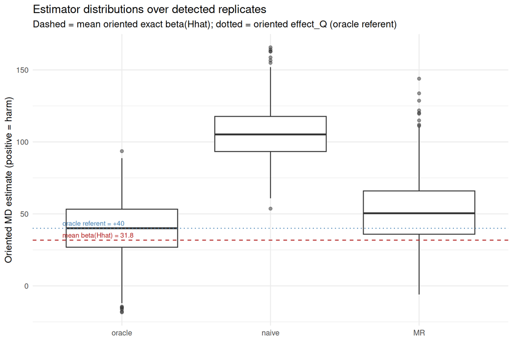

```r
if (nrow(rd)) {
  long <- do.call(rbind, lapply(names(est_keys), function(lab)
    data.frame(Estimator = lab, est = rd[[paste0(est_keys[[lab]], "_H_est")]])))
  long$Estimator <- factor(long$Estimator, levels = names(est_keys))
  bH_mean <- .mfin(rd$bH_or)
  ggplot(long[is.finite(long$est), ], aes(x = Estimator, y = est)) +
    geom_boxplot(outlier.alpha = 0.5) +
    geom_hline(yintercept = bH_mean, linetype = 2, colour = "firebrick") +
    geom_hline(yintercept = oracle_ref, linetype = 3, colour = "steelblue") +
    annotate("text", x = 0.6, y = bH_mean, vjust = -0.5, hjust = 0, size = 3,
             colour = "firebrick", label = sprintf("mean beta(Hhat) = %.1f", bH_mean)) +
    annotate("text", x = 0.6, y = oracle_ref, vjust = -0.5, hjust = 0, size = 3,
             colour = "steelblue", label = sprintf("oracle referent = %+.0f", oracle_ref)) +
    labs(y = "Oriented MD estimate (positive = harm)", x = NULL,
         title = "Estimator distributions over detected replicates",
         subtitle = "Dashed = mean oriented exact beta(Hhat); dotted = oriented effect_Q (oracle referent)") +
    theme_minimal(base_size = 12)
}
```

## 6.7 Identification

```r
if (nrow(rd)) {
  knitr::kable(data.frame(
    metric = c("sens", "spec", "ppv", "npv"),
    mean   = c(.mfin(rd$sens), .mfin(rd$spec), .mfin(rd$ppv), .mfin(rd$npv)),
    median = c(.medfin(rd$sens), .medfin(rd$spec), .medfin(rd$ppv), .medfin(rd$npv))),
    digits = 3, caption = "Classification of the identified subgroup vs the true harm flag (detected reps).")
}
```

Classification of the identified subgroup vs the true harm flag (detected reps).

| metric | mean | median |
| --- | --- | --- |
| sens | 0.171 | 0.159 |
| spec | 0.869 | 0.870 |
| ppv | 0.405 | 0.393 |
| npv | 0.665 | 0.663 |

### 6.7.1 Identification structure

```r
# Same package engine the survival template and the manuscript fragments use
# (fs_identification_summary()), so the three stay in step.  Classification
# keys on `sg_def`, which matters here: this harness leaves `covs` empty by
# design, and the manuscript's original inline version read `covs` directly --
# on these bundles that would have reported "anchor missed" on 100% of
# replicates without warning.
#
# THE TRIPLE IS NOT THE SURVIVAL ONE.  In the GBSG cell it is a continuous
# anchor (er), a true BINARY partner (meno), and a correlated CONTINUOUS proxy
# (age).  Here the true region is `age > 34 & preanti <= 744.5`: both true
# covariates are continuous, and the proxy is the reverse of the GBSG case --
# `str2`, the BINARY coarsening of the continuous partner.  The ACTG175
# literature is explicit that this coarsening is what limited earlier ITR
# methods (see the setup chunk for the measured relationships).
#
# NOTE: this row is meaningful only while include_str2 is TRUE (it is, in the
# setup chunk).  With str2 out of the candidate pool the proxy row would read
# 0% by construction rather than as a finding.
id_run <- fs_identification_summary(
  bundles = stats::setNames(list(results), as.character(n_sample)),
  anchor  = "age",       # true-region covariate 1 (z1: age > 34)
  partner = "preanti",   # true-region covariate 2 (z2: preanti <= 744.5)
  proxy   = "str2",      # the coarsened form of preanti -- see include_str2
  confounders = confounders_analysis,
  sweep_label = "Trial size (n)")
id_run
```

```
<fs_identification>
  triple : anchor = age | partner = preanti | proxy = str2
  sweep  : 500
  500      detection 100.0% of 1000; anchor recovered 44.0%
```

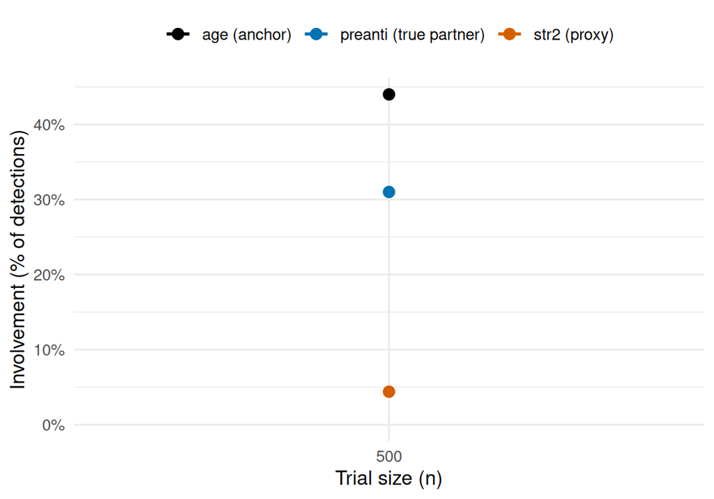

```r
plot_fs_identification_involvement(id_run)
```

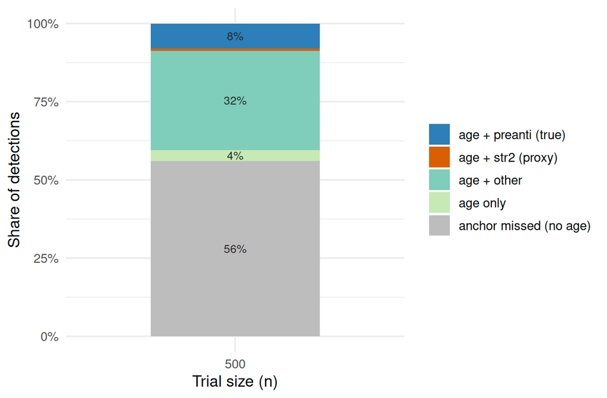

```r
plot_fs_identification_structure(id_run)
```

```r
fs_identification_table(id_run, as_gt = TRUE)
```

Identification structure across the sweep

anchor age | true partner preanti | proxy str2

| Quantity | 500 |
| --- | --- |
| Detection rate (all replicates) | 100.0% |
| age + preanti (true partner) | 8.0% |
| age + str2 (proxy partner) | 0.7% |
| age + other factor | 31.7% |
| age only | 3.6% |
| anchor missed (no age) | 56.0% |
| Anchor recovered (age, any pairing) | 44.0% |
| Conditional partner split, preanti : str2 | 92 : 8 |

Classification of the identified subgroup against the planted membership, averaged over detections (500): sensitivity 0.17, specificity 0.87, PPV 0.41, NPV 0.66.

### 6.7.2 Selected-covariate frequencies and realized rules

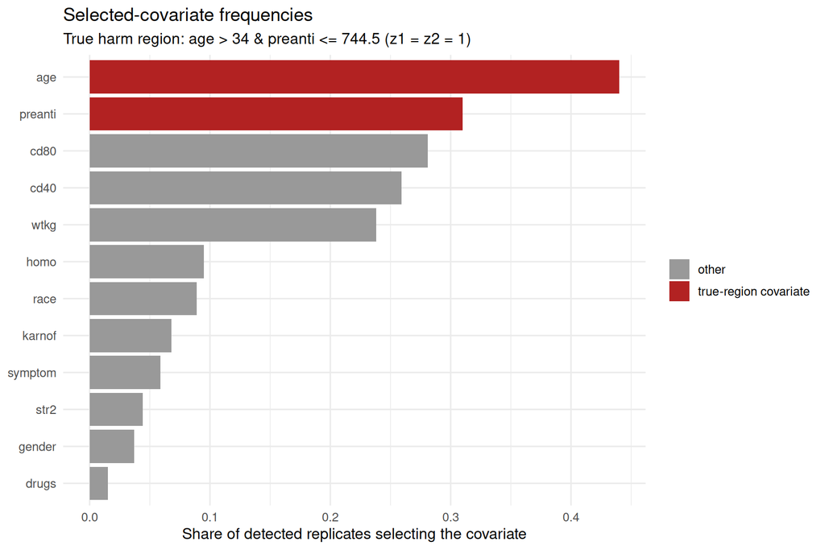

Realized rules (sg_def) by frequency, detected reps.

| rule | n | share |
| --- | --- | --- |
| !{age <= 35} & {age <= 39} | 4 | 0.004 |
| !{age <= 42} & {homo} | 4 | 0.004 |
| {drugs} | 4 | 0.004 |
| !{age <= 42} & !{preanti <= 0} | 3 | 0.003 |
| !{homo} & !{age <= 33} | 3 | 0.003 |
| !{homo} & !{age <= 36} | 3 | 0.003 |
| !{wtkg <= 82} & {str2} | 3 | 0.003 |
| {race} & !{age <= 32} | 3 | 0.003 |
| {race} & !{age <= 33} | 3 | 0.003 |
| {race} & {preanti <= 0} | 3 | 0.003 |
| {symptom} & !{age <= 30} | 3 | 0.003 |
| {symptom} & !{age <= 31} | 3 | 0.003 |
| {symptom} & !{race} | 3 | 0.003 |
| {symptom} & {homo} | 3 | 0.003 |
| !{age <= 28} & {age <= 32} | 2 | 0.002 |
| !{age <= 32} & {age <= 35} | 2 | 0.002 |
| !{age <= 37} & !{str2} | 2 | 0.002 |
| !{age <= 37} & {wtkg <= 74} | 2 | 0.002 |
| !{age <= 38} & {wtkg <= 75} | 2 | 0.002 |
| !{age <= 39} & !{wtkg <= 73} | 2 | 0.002 |
| !{age <= 39} & {age <= 45} | 2 | 0.002 |
| !{age <= 40} & !{wtkg <= 75} | 2 | 0.002 |
| !{age <= 42} & !{race} | 2 | 0.002 |
| !{cd40 <= 427} & {age <= 37} | 2 | 0.002 |
| !{cd80 <= 878} & !{age <= 40} | 2 | 0.002 |
| !{gender} & !{age <= 28} | 2 | 0.002 |
| !{gender} & {age <= 37} | 2 | 0.002 |
| !{homo} & !{age <= 35} | 2 | 0.002 |
| !{homo} & !{wtkg <= 75} | 2 | 0.002 |
| !{homo} & {age <= 30} | 2 | 0.002 |

[output cut: 892 more lines]

```r
# Retained alongside the structure summary above: the full covariate-frequency
# view over the whole analysis pool, and the realized-rule frequency table.
# These are twin-specific and complementary -- the structure summary classifies
# each rule into five categories, this shows the raw per-covariate shares.
if (nrow(rd)) {
  rule_covs <- function(rule) forestsearch:::.fs_rule_columns(rule)
  cov_list  <- lapply(rd$sg_def, rule_covs)
  cov_all   <- unique(unlist(cov_list))
  if (length(cov_all)) {
    cf <- vapply(cov_all, function(v)
      mean(vapply(cov_list, function(x) v %in% x, logical(1))), numeric(1))
    cf_df <- data.frame(covariate = names(cf), share = unname(cf))
    cf_df$true_region <- cf_df$covariate %in% c("age", "preanti")
    print(
      ggplot(cf_df, aes(x = reorder(covariate, share), y = share, fill = true_region)) +
        geom_col() + coord_flip() +
        scale_fill_manual(values = c(`TRUE` = "firebrick", `FALSE` = "grey60"),
                          labels = c(`TRUE` = "true-region covariate", `FALSE` = "other"),
                          name = NULL) +
        labs(x = NULL, y = "Share of detected replicates selecting the covariate",
             title = "Selected-covariate frequencies",
             subtitle = "True harm region: age > 34 & preanti <= 744.5 (z1 = z2 = 1)") +
        theme_minimal(base_size = 12))
    rules <- sort(table(rd$sg_def), decreasing = TRUE)
    knitr::kable(data.frame(rule = names(rules), n = as.integer(rules),
                            share = as.numeric(rules) / nrow(rd)),
      digits = 3, caption = "Realized rules (sg_def) by frequency, detected reps.")
  }
}
```

## 6.8 Timing

```r
.dist_row <- function(x) {
  x <- x[is.finite(x)]
  if (!length(x)) return(rep(NA_real_, 14))
  c(min = min(x), stats::quantile(x, probs = seq(0.1, 0.9, 0.1)),
    median = stats::median(x), mean = mean(x), max = max(x), n = length(x))
}
tim <- rbind(fit_mr_secs = .dist_row(results$fit_mr_secs),
             fb_secs     = .dist_row(results$fb_secs))
knitr::kable(tim, digits = 2,
  caption = sprintf("Per-replicate seconds (all replicates; %s mode, %d workers).",
                    parallel_mode, n_workers))
```

Per-replicate seconds (all replicates; sims mode, 115 workers).

|  | min | 10% | 20% | 30% | 40% | 50% | 60% | 70% | 80% | 90% | median | mean | max | n |
| --- | --- | --- | --- | --- | --- | --- | --- | --- | --- | --- | --- | --- | --- | --- |
| fit_mr_secs | 13.13 | 17.32 | 19.44 | 21.23 | 23.61 | 26.28 | 28.54 | 30.67 | 32.87 | 36.01 | 26.28 | 26.34 | 46.64 | 1000 |
| fb_secs | NA | NA | NA | NA | NA | NA | NA | NA | NA | NA | NA | NA | NA | NA |

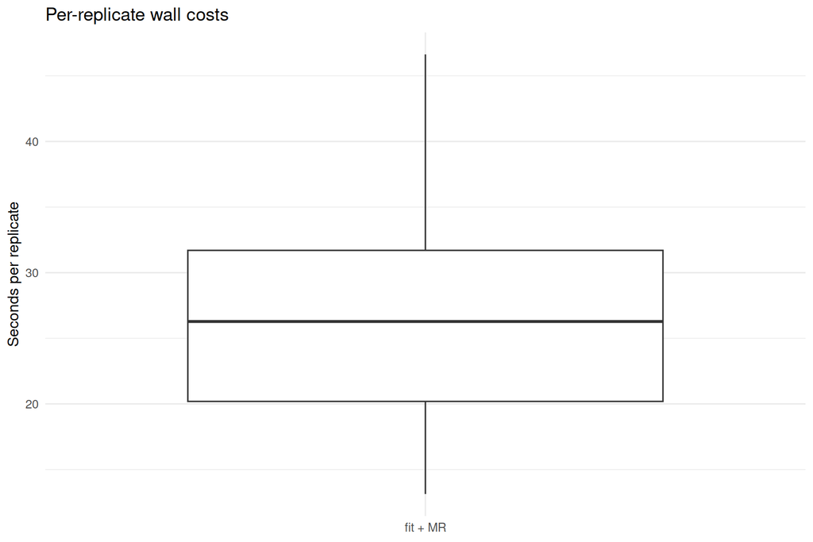

```r
tl <- rbind(data.frame(component = "fit + MR", secs = results$fit_mr_secs),
            data.frame(component = "FB bootstrap", secs = results$fb_secs))
tl <- tl[is.finite(tl$secs), , drop = FALSE]
if (nrow(tl)) {
  ggplot(tl, aes(x = component, y = secs)) +
    geom_boxplot(outlier.alpha = 0.6) +
    labs(x = NULL, y = "Seconds per replicate", title = "Per-replicate wall costs") +
    theme_minimal(base_size = 12)
}
```

```r
# Scale-up projection, ported from the combine document: measured per-replicate
# costs drive a busiest-worker wall model, calibrated by k = measured wall /
# modelled wall on THIS run.  Scenario knob -- edit freely.
proj_scenarios <- list(
  c(n_sims = 500L,  nb_boots = 300L),
  c(n_sims = 1000L, nb_boots = 300L),
  c(n_sims = 500L,  nb_boots = 500L)
)
mr_mean  <- .mfin(results$fit_mr_secs)
det_rate <- mean(results$detected %in% 1L)
boots_disp <- if (run_fb) as.integer(nb_boots) else 0L
fb_mean  <- if (run_fb) .mfin(results$fb_secs) else NA_real_
per_boot <- if (run_fb && boots_disp > 0L) fb_mean / boots_disp else NA_real_
fmt_hm <- function(sec) {
  if (!is.finite(sec)) return("-")
  h <- floor(sec / 3600); m <- round((sec - 3600 * h) / 60)
  if (h >= 1) sprintf("%d h %02d m", h, m) else sprintf("%d m", round(sec / 60))
}
per_rep_total <- function(B) {
  fb_rep <- if (run_fb && is.finite(per_boot)) per_boot * B else 0
  mr_mean + det_rate * fb_rep
}
wall_model <- function(ns, B) {
  if (identical(parallel_mode, "boots")) ns * per_rep_total(B)
  else ceiling(ns / n_workers) * per_rep_total(B)
}
wall_model_cur <- wall_model(n_batch, boots_disp)
k_cal <- if (is.finite(elapsed) && is.finite(wall_model_cur) && wall_model_cur > 0)
  elapsed / wall_model_cur else NA_real_
proj_row <- function(ns, B, actual_sec = NA_real_) {
  fb_rep  <- if (run_fb && is.finite(per_boot)) per_boot * B else NA_real_
  cpu_sec <- ns * per_rep_total(B)
  w_model <- wall_model(ns, B)
  data.frame(n_sims = ns, B = as.integer(B),
             mr_rep_s = round(mr_mean, 1),
             fb_rep_s = if (is.finite(fb_rep)) round(fb_rep, 0) else NA_real_,
             cpu_hours = round(cpu_sec / 3600, 1),
             wall_actual = fmt_hm(actual_sec),
             wall_model  = fmt_hm(w_model),
             wall_cal    = fmt_hm(if (is.finite(k_cal)) k_cal * w_model else NA_real_),
             stringsAsFactors = FALSE)
}
tab <- rbind(cbind(Scenario = "current run", proj_row(n_batch, boots_disp, actual_sec = elapsed)),
             cbind(Scenario = "projection",
                   do.call(rbind, lapply(proj_scenarios, function(s)
                     proj_row(s[["n_sims"]], s[["nb_boots"]])))))
cat(sprintf("Current run: %d reps in %.0f s on %d workers. Per rep: fit+MR %.1f s%s. Detection %.0f%%.\n",
            n_batch, elapsed, n_workers, mr_mean,
            if (run_fb) sprintf(", FB %.0f s (B=%d, ~%.1f s/bootstrap)",
                                fb_mean, boots_disp, per_boot) else " (FB skipped)",
            100 * det_rate))
```

```
Current run: 1000 reps in 455 s on 115 workers. Per rep: fit+MR 26.3 s (FB skipped). Detection 100%.
```

```r
if (is.finite(k_cal))
  cat(sprintf("Realized overhead factor k = %.2f (measured wall / busiest-worker model).\n", k_cal))
```

```
Realized overhead factor k = 1.92 (measured wall / busiest-worker model).
```

```r
gt(tab) |>
  tab_header(title = "Wall-clock projection",
             subtitle = sprintf("%s mode - %d workers - detection %.0f%%%s",
                                parallel_mode, n_workers, 100 * det_rate,
                                if (is.finite(k_cal)) sprintf(" - k = %.2f", k_cal) else "")) |>
  cols_label(n_sims = "sims", B = "boots", mr_rep_s = "fit+MR/rep (s)",
             fb_rep_s = "FB/rep (s)", cpu_hours = "CPU-hours",
             wall_actual = "wall (actual)", wall_model = "wall (modeled)",
             wall_cal = "wall (calibrated)") |>
  tab_footnote(footnote = md(paste(
    "QUICK-RUN CAVEAT: per-bootstrap cost is measured at B =",
    sprintf("%d,", boots_disp),
    "well below production; fixed per-replicate FB overhead is amortized over",
    "far fewer bootstraps here, so the projected FB/rep at B = 300-500 likely",
    "OVERSTATES the true cost.  Model: `wall (modeled)` =",
    if (identical(parallel_mode, "boots"))
      "sims x per-rep cost (replicates sequential);"
    else "ceil(sims / workers) x per-rep cost (replicates parallel, bootstrap sequential);",
    "per-rep cost = fit+MR/rep + detection x FB/rep.",
    "`wall (calibrated)` = k x modeled, with k fit on THIS run.")))
```

Wall-clock projection

sims mode - 115 workers - detection 100% - k = 1.92

| Scenario | sims | boots | fit+MR/rep (s) | FB/rep (s) | CPU-hours | wall (actual) | wall (modeled) | wall (calibrated) |
| --- | --- | --- | --- | --- | --- | --- | --- | --- |
| current run | 1000 | 0 | 26.3 | NA | 7.3 | 8 m | 4 m | 8 m |
| projection | 500 | 300 | 26.3 | NA | 3.7 | - | 2 m | 4 m |
| projection | 1000 | 300 | 26.3 | NA | 7.3 | - | 4 m | 8 m |
| projection | 500 | 500 | 26.3 | NA | 3.7 | - | 2 m | 4 m |

QUICK-RUN CAVEAT: per-bootstrap cost is measured at B = 0, well below production; fixed per-replicate FB overhead is amortized over far fewer bootstraps here, so the projected FB/rep at B = 300-500 likely OVERSTATES the true cost. Model: `wall (modeled)` = ceil(sims / workers) x per-rep cost (replicates parallel, bootstrap sequential); per-rep cost = fit+MR/rep + detection x FB/rep. `wall (calibrated)` = k x modeled, with k fit on THIS run.

```r
.fmt_dur <- function(s) {
  h <- s %/% 3600; m <- (s %% 3600) %/% 60; sec <- round(s %% 60)
  if (h >= 1) sprintf("%d h %02d m %02d s", h, m, sec)
  else if (m >= 1) sprintf("%d m %02d s", m, sec)
  else sprintf("%.1f s", s)
}
.secs_total <- as.numeric(difftime(Sys.time(), .t0_doc, units = "secs"))
cat(sprintf("TOTAL wall-clock, start to finish: %s  (= %.0f s; %d reps on %d workers)\n",
            .fmt_dur(.secs_total), .secs_total, n_batch, n_workers))
```

```
TOTAL wall-clock, start to finish: 7 m 41 s  (= 461 s; 1000 reps on 115 workers)
```

```r
cat(sprintf("  of which the run loop: %s\n", .fmt_dur(elapsed)))
```

```
  of which the run loop: 7 m 35 s
```

Combine across batches with the template’s `run_mode = "combine"` pattern once multiple pieces exist; the combine-and-report twin (of `..._combine_1_500.qmd`) follows as the next document.